# MUSA508_MidtermProject: Home Price Predictions in Miami, FL & Miami Beach, FL

Kristin Chang and Jenna Epstein

10/16/2020

# Introduction

## What is the purpose of this project?

The purpose of this project is to build a better predictive model of home prices for Miami and Miami Beach, Florida. Our process follows the hedonic price prediction method, where the sale price of each house is determined by both internal characteristics of the house, and external characteristics that take into account local context. We draw upon open data sources to determine the relevant external features to incorporate into our model. Ultimately we use ordinary least squares (OLS) regression to estimate goodness of fit for our model.

## Why should we care about it?

Home price prediction is a common use case for cities, as they leverage data for a variety of purposes, from tax assessments to land use to zoning. In looking to build a better predictive model for home prices, it is imperative to look beyond internal features and incorporate local context that influence buyers’ decision making.

## What makes this a difficult exercise?

Another challenge involves the lack of open data standardization and availability across Miami and Miami Beach. Both cities sit within the county of Miami-Dade, but the county’s open data portal does not contain the same level of data across the various municipalities. The city of Miami also has an additional open data portal, and while some of the data sources may be useful for feature engineering, it is only available at the Miami city level, and thus cannot be used in our analysis of two areas.

## What is your overall modeling strategy?

Our overall modeling strategy involves robust feature engineering to account for contextual differences that may influence sale price. We start with internal feature engineering, based on the data provided. New variables are created to separate out houses that have a pool. We then move on to bringing in additional data to engineer external features and associate them with the dataset of houses provided. We then fit multiple statistical models using different combinations of features in order to get a best fit for our dataset. Details about the robust data collection and wrangling for new features as well as details about our statistical methods are discussed more in the following sections.

## Briefly summarize your results.

Through exploratory analysis and statistical modeling, we determine that crime, zoning, flood risk insurance zone, distance to the coast, neighborhood, and presence of a pool are key factors when predicting future home sales prices. Our final model is the neighborhood model that factors in spatial processes that cause clustering in sales price.

```r
library(tidyverse)
library(sf)
library(spdep)
library(caret)
library(ckanr)
library(FNN)
library(grid)
library(gridExtra)
library(ggcorrplot)
library(osmdata)
library(jtools)
library(broom)
library(broom.mixed)
library(stringr)
library(RANN)
library(tidymodels)
library(tidycensus)
library(kableExtra)
library(nngeo)
library(viridis)
options(tigris_class = "sf")
options(tigris_use_cache = TRUE)
options(scipen=999)

root.dir = "https://raw.githubusercontent.com/kristinchang/MUSA508_MidtermProject"

mapTheme <- function(base_size = 12) {
  theme(
    text = element_text( color = "black"),
    plot.title = element_text(size = 14,colour = "black"),
    plot.subtitle=element_text(face="italic"),
    plot.caption=element_text(hjust=0),
    axis.ticks = element_blank(),
    #panel.background = element_blank(),axis.title = element_blank(),
    #axis.text = element_blank(),
    axis.title.x = element_blank(),
    axis.title.y = element_blank(),
   # panel.grid.minor = element_blank(),
    panel.border = element_rect(colour = "black", fill=NA, size=2)
  )
}

plotTheme <- function(base_size = 12) {
  theme(
    text = element_text( color = "black"),
    plot.title = element_text(size = 14,colour = "black"),
    plot.subtitle = element_text(face="italic"),
    plot.caption = element_text(hjust=0),
    axis.ticks = element_blank(),
    panel.background = element_blank(),
    panel.grid.major = element_line("grey80", size = 0.1),
    panel.grid.minor = element_blank(),
    panel.border = element_rect(colour = "black", fill=NA, size=2),
    strip.background = element_rect(fill = "grey80", color = "white"),
    strip.text = element_text(size=12),
    axis.title = element_text(size=12),
    axis.text = element_text(size=10),
    plot.background = element_blank(),
    legend.background = element_blank(),
    legend.title = element_text(colour = "black", face = "italic"),
    legend.text = element_text(colour = "black", face = "italic"),
    strip.text.x = element_text(size = 14)
  )
}

palette5 <- c("#25CB10", "#5AB60C", "#8FA108",   "#C48C04", "#FA7800")

# Helper Functions
qBr <- function(df, variable, rnd) {
  if (missing(rnd)) {
    as.character(quantile(round(df[[variable]],0),
                          c(.01,.2,.4,.6,.8), na.rm=T))
  } else if (rnd == FALSE | rnd == F) {
    as.character(formatC(quantile(df[[variable]]), digits = 3),
                          c(.01,.2,.4,.6,.8), na.rm=T)
  }
}

q5 <- function(variable) {as.factor(ntile(variable, 5))}

## nn function
nn_function <- function(measureFrom,measureTo,k) {
  measureFrom_Matrix <- as.matrix(measureFrom)
  measureTo_Matrix <- as.matrix(measureTo)
  nn <-
    get.knnx(measureTo, measureFrom, k)$nn.dist
    output <-
      as.data.frame(nn) %>%
      rownames_to_column(var = "thisPoint") %>%
      gather(points, point_distance, V1:ncol(.)) %>%
      arrange(as.numeric(thisPoint)) %>%
      group_by(thisPoint) %>%
      summarize(pointDistance = mean(point_distance)) %>%
      arrange(as.numeric(thisPoint)) %>%
      dplyr::select(-thisPoint) %>%
      pull()

  return(output)
}
```

# Data

## Initial Data

First, we read in the provided geojson dataset containing the properties. To get an idea of the study area that we are working with, we read in a basemap using the county’s open data hub for the Miami City and Miami Beach areas. The City of Miami is shown at the neighborhood level; there is no available open neighborhood boundary data for Miami Beach, so for the purposes of this analysis, Miami Beach is treated as a single neighborhood. We acknowledge that there are limitations looking at such a large area as one unit. This will be acknowledged more later in the discussion on neighborhood fixed effects and spatial correlation.

```r
# read in the provided dataset, calling it "miamiHouses". Since Folios are sometimes repeated, in case we need to reference a specific row later, creating a new column for unique observation number.
miamiHouses <-
  st_read("studentsData.geojson") %>%
  mutate(observation= 1:n()) %>%
  st_transform('ESRI:102658')

# Converting the given data into points for certain feature engineering cases
miamiHouses <- miamiHouses %>%
  st_centroid(miamiHouses)

miamiHousesPts <- miamiHouses %>%
 st_as_sf(coords = c("Longitude", "Latitude"), crs = 4326, agr = "constant") %>%
st_transform(4326)
```

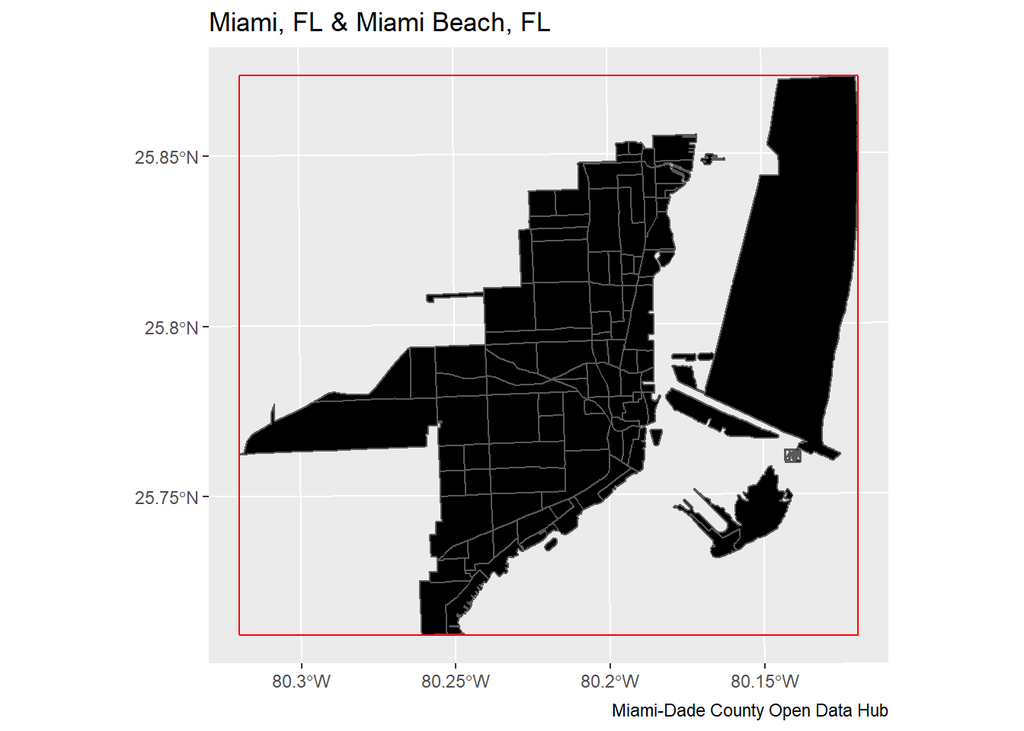

```r
## Creating a new basemap with neighborhoods
miami.city.nhoods <-
  st_read("https://opendata.arcgis.com/datasets/2f54a0cbd67046f2bd100fb735176e6c_0.geojson") %>%
st_transform('ESRI:102658') %>%
  dplyr::select(-FID, -Shape_STAr, -Shape_STLe, -Shape__Area, -Shape__Length) %>%
  dplyr::rename(NAME = LABEL)

## miami beach - treating it as its own neighborhood
miami.beach <- st_read("https://opendata.arcgis.com/datasets/5ece0745e24b4617a49f2e098df8117f_0.geojson") %>%
  filter(NAME == "MIAMI BEACH") %>%
  st_transform('ESRI:102658') %>%
  dplyr::select(-FID, -MUNICUID, -MUNICID, -SHAPE_Area, -SHAPE_Length, -CREATEDBY, -FIPSCODE, -MODIFIEDBY, -MODIFIEDDATE, -CREATEDDATE)

## union
miami.nhoods <- rbind(miami.city.nhoods,miami.beach)

## bounding box
xmin = st_bbox(miami.nhoods)[[1]]
ymin = st_bbox(miami.nhoods)[[2]]
xmax = st_bbox(miami.nhoods)[[3]]
ymax = st_bbox(miami.nhoods)[[4]]

ggplot() +
  geom_sf(data=miami.nhoods, fill="black") +
  geom_sf(data=st_as_sfc(st_bbox(miami.nhoods)), colour="red", fill=NA) +
 labs(title = "Miami, FL & Miami Beach, FL",
         caption = "Miami-Dade County Open Data Hub")
```

We also create a basemap with its own bounding box to be used when pulling in features from OpenStreetMap (OSM). This unioned OSM basemap is not projected - any OSM feature data used will be transformed to the proper CRS after OSM data is retrieved from OSM’s overpass API.

## Internal Features

### Pool

We leverage the dataset to engineer a new internal feature: Pool. This involves extracting the string “Pool” from the XF1 column (the “Extra Features” column where pools were listed) and assigning each house as “Yes” (having a pool) or “No” (not having a pool). Given the heat in the Miami area, we figure that having a private pool is likely to influence the sale value of a house. We use this in our final model.

### Zoning

We select zoning as a feature to incorporate in our models. Looking at the dataset, not all houses are situated within residential zoning areas (single family homes, multi-family homes, duplexes, townhouses, and estates). Given the effects that zoning can have on house prices and value fluctuations (especially for residential areas adjacent to industrial or commercial areas), we felt it was important to incorporate in our exploration. We use this in our final model.

### Additional Internal Home Features

```r
## Creating a new variable by extracting "Pool" from the XF1 column. Instances of pools only occur in the first XF column.
miamiHousesPts <-
  miamiHousesPts %>%
  mutate(Pool= ifelse(str_detect(miamiHouses$XF1, "Pool"), "Yes", "No"))
## Creating a new variable for age of house. Using 2020 as the current year.

miamiHousesPts <-
  miamiHousesPts %>%
  mutate(Age = 2020 - YearBuilt)
miamiHousesPts$Age <- as.numeric(miamiHousesPts$Age)  # Convert Age variable to numeric
```

## External Features

We now turn to engineering and including external features by bringing in available open data.

### Distance to Coast (miles)

```r
# First, pull coastline data from OpenStreetMap in an xml format. Note that we are calculating this feature before reprojecting studentsDataPts back to ESRI projection. Has to be in Lat/Lon to work for distance calculation.
coastline<-opq(bbox = c(xmin.osm, ymin.osm, xmax.osm, ymax.osm)) %>%
  add_osm_feature("natural", "coastline") %>%
  osmdata_xml('coastline.osm')

# Then, read it back into R and transform it into an sf.
coastline.sf <- sf::st_read('coastline.osm', layer = 'lines') %>%
  st_as_sf(coords = c("Long", "Lat"), crs = 4326, agr = "constant")

# Add to main data and convert to miles
miamiHousesPts <-
  miamiHousesPts %>%
  st_transform(st_crs(coastline.sf)) %>%
  mutate(distCoast=(geosphere::dist2Line(p=st_coordinates(miamiHousesPts), line=st_coordinates(coastline.sf)[,1:2])*0.00062137)[,1])

# distcoast - log
# to remove negatives, taking 5-
miamiHousesPts <- miamiHousesPts %>%
  dplyr::mutate(distCoast.log=5-log(distCoast))
```

Now that coastline distance is calculated and included as a feature, we reproject our main data.

```r
miamiHouses.sf <-
  miamiHousesPts %>%
  st_as_sf(coords = c("Long", "Lat"), crs = 4326, agr = "constant") %>%
  st_transform('ESRI:102658')
```

### FEMA Flood Insurance Rate Zones

Given the proximity of Miami and Miami Beach to the ocean and increasing prevalence of tropical storms inundating lower-lying areas of South Florida, we seek to include a feature to account for flood insurance zones. Through Miami-Dade County’s open data hub, we read in a geojson file containing polygons for all of the FEMA-designated flood insurance rate zones in the county. We then do a spatial join of the flood zone polygons and the main data set to associate each house with whatever zone in which it is situated. Here are the definitions of each flood insurance zone within our study area. For more information, please visit https://www.miamidade.gov/environment/flood-maps.asp).

[output not shown]

The map below illustrates Miami and Miami Beach houses color-coded by zone.

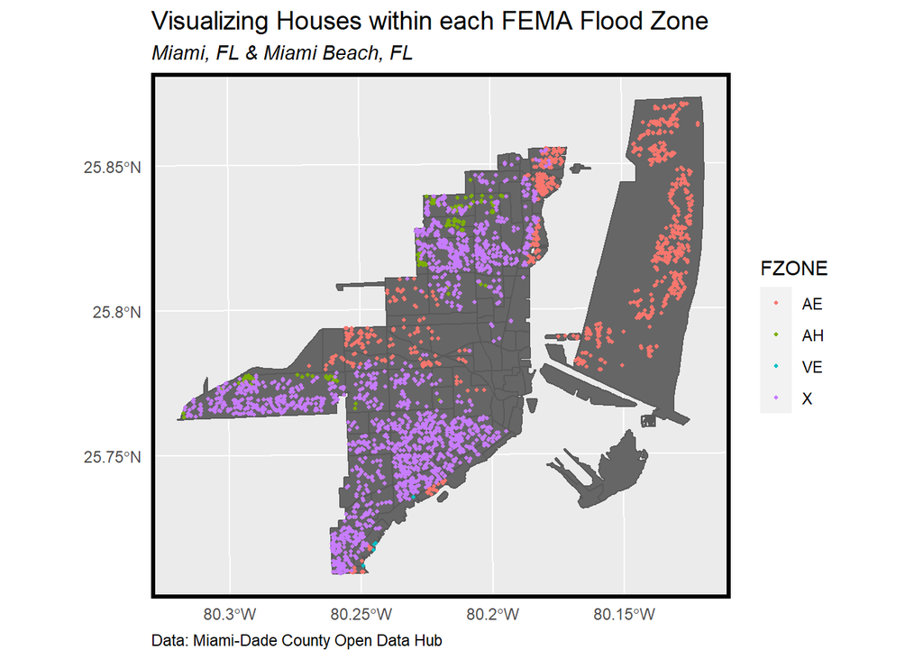

```r
# https://www.miamidade.gov/environment/flood-maps.asp
# ZONE AE (Moderate to High Flooding Risk) This is the flood insurance rate zone that corresponds with flood depths greater than three feet. Mandatory flood insurance purchase requirements apply.

# creating a new variable indicating whether the house sits within zone AE or VE. These are zones with risk greater than three feet and additional hazards (coastal areas).

# joining floodzones with miami houses
miamiHouses.sf <- st_join(miamiHouses.sf, floodzones, join = st_within)

# in case we want to isolate Zone AE later
miamiHouses.sf <- miamiHouses.sf %>%
  mutate(HighFloodRisk=ifelse(str_detect(miamiHouses.sf$FZONE, "AE"), "yes", "no"))

ggplot() +
  geom_sf(data=miami.nhoods, fill="grey40")+
  geom_sf(data=miamiHouses.sf, size=0.75, aes(color=FZONE)) +
  labs(title="Visualizing Houses within each FEMA Flood Zone",
       subtitle="Miami, FL & Miami Beach, FL",
       caption = "Data: Miami-Dade County Open Data Hub") +
  mapTheme()
```

Now that we have finished doing calculations involving OpenStreetMap data, we join the houses with the neighborhoods data. Each house is assigned to the neighborhood polygon that it sits within.

```r
miamiHouses.sf <- st_join(miamiHouses.sf, miami.nhoods, join = st_within)
```

Before conducting some additional external feature engineering, we partition our provided dataset into two groups: one with past known sales prices and one with unknown sales prices for which we will predict. We further partition the known sales price group into two separate datasets: a **training dataset** that we will use to observe features’ relationships with sales prices and build our statistical models, and a **validation dataset** that we will use to test the accuracy and generalizability of our models. Once we are able to confirm that a model is accurate and generalizable (will be accurate when applied to data with unknown sales prices), we will input the data with unknown sales prices to produce estimates.

```r
## separating training and testing data
 miamiTrain.sf <-
  filter (miamiHouses.sf, toPredict == "0") %>%
  distinct(.keep_all = TRUE)

##splitting training set into training and validation DFs by 60% x 40%
inTrain <- createDataPartition(
  y = paste(miamiTrain.sf$Stories.cat, miamiTrain.sf$Zoning, miamiTrain.sf$Mailing.Zip, miamiTrain.sf$NAME, miamiTrain.sf$Bed),
  p = .60, list = FALSE)

trainSet.sf <- miamiTrain.sf[inTrain,]
validSet.sf <- miamiTrain.sf[-inTrain,]

miamiTest <-
  filter (miamiHouses.sf, toPredict == "1")
```

## Summary Statistics: All Houses with Known Sales Prices

First, we look at the continuous variables from our original dataset and calculate summary statistics to get an idea of the distribution among all houses within the dataset that contain sales prices.

```r
train_variables <-c("ActualSqFt", "Bed", "Bath", "Stories", "Age", "LotSize")

means <-c(mean(miamiTrain.sf$ActualSqFt),mean(miamiTrain.sf$Bed),mean(miamiTrain.sf$Bath),mean(miamiTrain.sf$Stories), mean(miamiTrain.sf$Age), mean(miamiTrain.sf$LotSize))

medians <-c(median(miamiTrain.sf$ActualSqFt),median(miamiTrain.sf$Bed),median(miamiTrain.sf$Bath),median(miamiTrain.sf$Stories), median(miamiTrain.sf$Age), median(miamiTrain.sf$LotSize))

sds <-c(sd(miamiTrain.sf$ActualSqFt),sd(miamiTrain.sf$Bed),sd(miamiTrain.sf$Bath),sd(miamiTrain.sf$Stories), sd(miamiTrain.sf$Age), sd(miamiTrain.sf$LotSize))

var_table<-
data.frame(row.names = train_variables, check.rows = FALSE,
        check.names = TRUE)
var_table$Mean <- means
var_table$Median<- medians
var_table$StandardDeviation <- sds

var_table %>% kable(caption = "Summary Statistics: All Houses with Known Sales Prices") %>% kable_styling(bootstrap_options = c("striped", "condensed", "responsive", fixed_thead=T, font_size=10, bold=T))
```

Summary Statistics: All Houses with Known Sales Prices

|  | Mean | Median | StandardDeviation |
| --- | --- | --- | --- |
| ActualSqFt | 2356.205894 | 1829 | 1839.1215838 |
| Bed | 3.000807 | 3 | 1.1091480 |
| Bath | 2.077917 | 2 | 1.3291139 |
| Stories | 1.199839 | 1 | 0.4394151 |
| Age | 68.326201 | 73 | 22.9681984 |
| LotSize | 7708.258950 | 6600 | 4751.5209454 |

For our other external feature engineering, we bring in the data and run the nearest neighbor function for all houses within our training and validation sets.

### Crime Incidents (Burglary and Assault, May - September 2020)

Incorporating crime as a feature in our analysis requires data wrangling. Unlike the other open data obtained through the county’s portal, Miami-Dade hosts their crime data through a third-party mapping site (https://www.crimemapping.com/map/fl/miami-dadecounty). The data is publicly available for several categories of incidents occurring over the previous six months (from the user’s date of access). While it allows users view block-level locations of incidents, share maps, and print the data in table format, it does not have the functionality for downloading the tables in a csv format. This requires us to scrape the data from the printable tables into a digital spreadsheet. We decide to use burglary and assault incidents, as they are the ones in the past full few months that appear without our study area. The data is available at the block level, but there are no further geographical attributes associated with it. We leverage the tidygeocoder R package to geocode the block-level data and obtain coordinates. Given the block-level data provided, the geocoder also returns block-level addresses instead of more granular addresses. We acknowledge the spatial bias involved in associating houses with data based on block-level proximity. However, given that this is the most granularity available, we use the nearest neighbor function to account for crime exposure within a given distance of each house.

In the series of scatterplots below, the data points hug the lines, especially in the lower left sections. This suggests there is some correlation between sale price and crime exposure. We will explore this further in our multivariate regressions.

```r
# Bring in geocoded data and transform it to an sf
crimes <-
  st_read('miami_city_crime_data_merged.csv')

crimes.sf <- crimes %>%
  dplyr::select(lat, long, street) %>%
  st_as_sf(coords = c("long", "lat"), crs = 4326, agr = "constant") %>%
  st_transform('ESRI:102658')

# Nearest Neighbors
st_c <- st_coordinates

trainSet.sf <-
  trainSet.sf %>%
    mutate(
      crime_nn1 = nn_function(st_c(st_centroid(trainSet.sf)), st_c(crimes.sf), 1),
      crime_nn2 = nn_function(st_c(st_centroid(trainSet.sf)), st_c(crimes.sf), 2),
      crime_nn3 = nn_function(st_c(st_centroid(trainSet.sf)), st_c(crimes.sf), 3),
      crime_nn4 = nn_function(st_c(st_centroid(trainSet.sf)), st_c(crimes.sf), 4),
      crime_nn5 = nn_function(st_c(st_centroid(trainSet.sf)), st_c(crimes.sf), 5))

validSet.sf <-
  validSet.sf %>%
      mutate(
      crime_nn1 = nn_function(st_c(st_centroid(validSet.sf)), st_c(crimes.sf), 1),
      crime_nn2 = nn_function(st_c(st_centroid(validSet.sf)), st_c(crimes.sf), 2),
      crime_nn3 = nn_function(st_c(st_centroid(validSet.sf)), st_c(crimes.sf), 3),
      crime_nn4 = nn_function(st_c(st_centroid(validSet.sf)), st_c(crimes.sf), 4),
      crime_nn5 = nn_function(st_c(st_centroid(validSet.sf)), st_c(crimes.sf), 5))
```

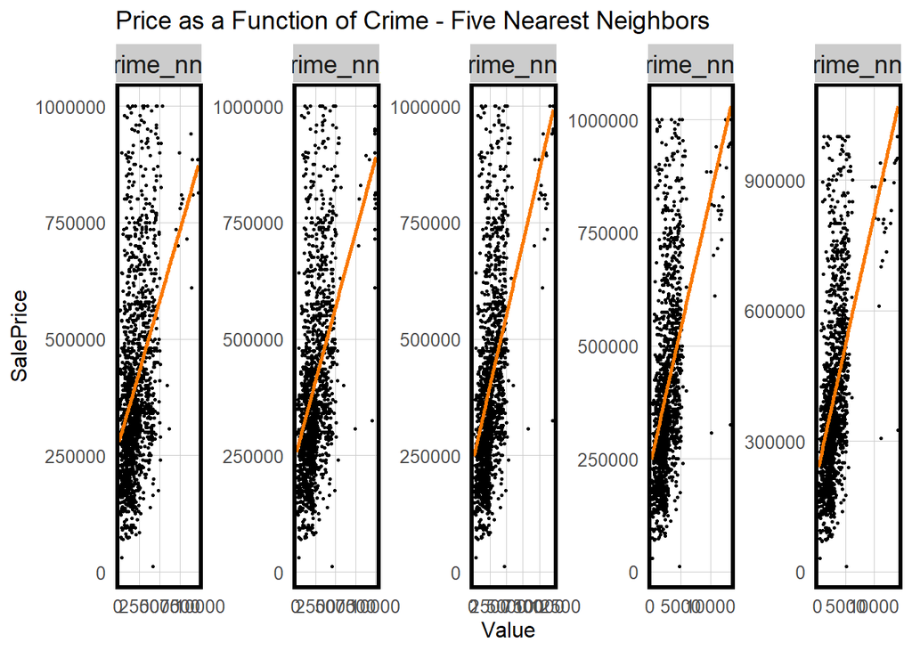

```r
# Home Features cor
st_drop_geometry(trainSet.sf) %>%
  dplyr::select(SalePrice, starts_with("crime_")) %>%
  filter(SalePrice <= 1000000) %>%
  gather(Variable, Value, -SalePrice) %>%
   ggplot(aes(Value, SalePrice)) +
     geom_point(size = .5) + geom_smooth(method = "lm", se=F, colour = "#FA7800") +
     facet_wrap(~Variable, nrow = 1, scales = "free") +
     labs(title = "Price as a Function of Crime - Five Nearest Neighbors") +
     plotTheme()
```

### Parks

We bring in a point-level dataset, provided through Miami-Dade County’s open data hub, for park locations within Miami-Dade County. We run the nearest neighbor function to obtain distances to the five nearest neighbors; however, in exploring the relationships to the house prices in both the univariate and multivariate tests, we decide to exclude parks.

```r
parks <- st_read("https://opendata.arcgis.com/datasets/8c9528d3e1824db3b14ed53188a46291_0.geojson") %>%
  filter(CITY == "Miami Beach" | CITY == "Miami" | CITY == "MIAMI" | CITY == "MIAMI BEACH") %>%
  st_transform('ESRI:102658') %>%
   .[miami.nhoods,]

# cleaning parks
parks.sf <-
  parks %>%
    dplyr::select(LAT, LON) %>%
    na.omit() %>%
     .[miami.nhoods,] %>%
    st_transform('ESRI:102658')
## Nearest neighbors for parks.
st_c <- st_coordinates

trainSet.sf <-
  trainSet.sf %>%
  mutate(
    parks_nn1 = nn_function(st_c(st_centroid(trainSet.sf)), st_c(parks.sf), 1),
    parks_nn2 = nn_function(st_c(st_centroid(trainSet.sf)), st_c(parks.sf), 2),
    parks_nn3 = nn_function(st_c(st_centroid(trainSet.sf)), st_c(parks.sf), 3),
    parks_nn4 = nn_function(st_c(st_centroid(trainSet.sf)), st_c(parks.sf), 4),
    parks_nn5 = nn_function(st_c(st_centroid(trainSet.sf)), st_c(parks.sf), 5))

validSet.sf <-
  validSet.sf %>%
  mutate(
    parks_nn1 = nn_function(st_c(st_centroid(validSet.sf)), st_c(parks.sf), 1),
    parks_nn2 = nn_function(st_c(st_centroid(validSet.sf)), st_c(parks.sf), 2),
    parks_nn3 = nn_function(st_c(st_centroid(validSet.sf)), st_c(parks.sf), 3),
    parks_nn4 = nn_function(st_c(st_centroid(validSet.sf)), st_c(parks.sf), 4),
    parks_nn5 = nn_function(st_c(st_centroid(validSet.sf)), st_c(parks.sf), 5))
```

### Dining Establishments (Bars, Pubs, Restaurants, Cafes)

Using the osmdata package, we pull point-level data for restaurants, bars, pubs, and cafes within our study area from OpenStreetMap. As done with parks, we run the nearest neighbor function to obtain distances to the five nearest neighbors; however, in exploring the relationships to the house prices in both the univariate and multivariate tests, we decide to exclude dining.

```r
## Using OSM to plot bars, pubs, and restaurants as points
dining <- opq(bbox = c(xmin.osm, ymin.osm, xmax.osm, ymax.osm)) %>%
    add_osm_feature(key = 'amenity', value = c("bar", "pub", "restaurant", "cafe")) %>%
    osmdata_xml(filename = 'dining.osm')


dining <- sf::st_read('dining.osm', layer = 'points') %>%
  .[miami.nhoods.osm,] %>%
  st_as_sf(coords = c("LON", "LAT"), crs = 4326, agr = "constant") %>%
  st_transform('ESRI:102658')

# cleaning osm dining
dining.sf <-
  dining %>%
    st_transform(st_crs(trainSet.sf))

st_c <- st_coordinates

trainSet.sf <-
  trainSet.sf %>%
  mutate(
    dining_nn1 = nn_function(st_c(st_centroid(trainSet.sf)), st_c(st_centroid(dining.sf)), 1),
    dining_nn2 = nn_function(st_c(st_centroid(trainSet.sf)), st_c(st_centroid(dining.sf)), 2),
    dining_nn3 = nn_function(st_c(st_centroid(trainSet.sf)), st_c(st_centroid(dining.sf)), 3),
    dining_nn4 = nn_function(st_c(st_centroid(trainSet.sf)), st_c(st_centroid(dining.sf)), 4),
    dining_nn5 = nn_function(st_c(st_centroid(trainSet.sf)), st_c(st_centroid(dining.sf)), 5))

validSet.sf <-
  validSet.sf %>%
  mutate(dining_nn1 = nn_function(st_c(st_centroid(validSet.sf)), st_c(st_centroid(dining.sf)), 1),
    dining_nn2 = nn_function(st_c(st_centroid(validSet.sf)), st_c(st_centroid(dining.sf)), 2),
    dining_nn3 = nn_function(st_c(st_centroid(validSet.sf)), st_c(st_centroid(dining.sf)), 3),
    dining_nn4 = nn_function(st_c(st_centroid(validSet.sf)), st_c(st_centroid(dining.sf)), 4),
    dining_nn5 = nn_function(st_c(st_centroid(validSet.sf)), st_c(st_centroid(dining.sf)), 5))
```

### Elevation

Data for distance to the coastline coupled data for flood zone identification leads us to explore including elevation as an external feature. Elevation data is available to the public as raster data. This requires us to perform some additional data wrangling to transform it into a usable format for exploration and analysis. This involves downloading the most recent 5-feet Digital Elevation Model (DEM) from the United States Geological Survey and reading it into R using the raster library. After projecting it to the correct coordinate reference system, we convert it to a spatial points dataframe using the rasterToPoints function. Given the large size of this file and the amount of time for R to process it, we write it to a csv and remove all of the hundreds of coordinate points that fall well outside of Miami-Dade county. We then read the csv file back in, transform it to a simple features object, ensure it is transformed to the same coordinate reference system as our main data, and spatial join each point to the nearest house in our dataset using the st_nearest_feature join predicate . Finally, we convert this new elevation variable to numeric in order to explore the relationship between nearest elevation value and home price. As with the previous two additional features, we decide to exclude this. Our numeric variable for distance to coast and our categorical variable for flood zone identification ultimately prove to be better combined predictors in our tests to account for what effects elevation levels may have on prices. This makes sense because a lot of houses in Miami Beach especially sit at low elevations, but are still highly priced because of the desirability of location. Those choosing to live right on the beach may not have an issue with paying more money for flood insurance living in a higher risk zone right next to the coast.

```r
## ELEVATION - DIGITAL ELEVATION MODEL FROM USGS
# data wrangling and prep work - no need to run the commented out work

#library(raster)
##miamiDEM <- raster("USGS_13_n26w081_Clip1.tif")
##crs(miamiDEM) <- CRS('+proj=tmerc +lat_0=24.33333333333333 +lon_0=-81 +k=0.999941177 +x_0=200000.0001016002 +y_0=0 +ellps=GRS80 +datum=NAD83 +to_meter=0.3048006096012192 +no_defs')
##plot(miamiDEM)
#convert to spatial points dataframe
##miamiDEM.spdf <- rasterToPoints(miamiDEM, fun=NULL, spatial=TRUE)
# wrote it to a csv to make it easier to read in
##write.csv(miamiDEM.df,"miamiDEM.csv")
##plot(miamiDEM.spdf)

# To run, START HERE - read in new csv
#miamiElevation <- st_read('miamiDEM_clipped.csv')

#convert to sf
#miamiElevation.sf <- miamiElevation %>%
 # st_as_sf(coords = c("Long", "Lat"), crs = 4326, agr = "constant") %>%
  #st_transform(st_crs(miamiHouses.sf))

#miamiHouses.sf = st_join(miamiHouses.sf, miamiElevation.sf, join=st_nearest_feature, left=TRUE)
#miamiHouses.sf$elevation <- as.numeric(as.character(miamiHouses.sf$elevation))  # Convert elevation variable to numeric
```

# Methods

After engineering both internal and external features, we conduct some more exploratory analysis in order to observe each feature’s relationship with past sales prices. This analysis allows us to identify which features have the greatest significance when it comes to predicting future sales prices. Statistical models allow us to produce estimates of sales prices based on the selected feature characteristics.

## Summary Statistics: Houses with Known Sales Price in the Training Dataset

This table shows the summary statistics for continuous variables from the **training** subset of our original dataset. Note that we ultimately do not include parks or dining in our final model.

```r
train_variables2 <-c("ActualSqFt", "Bed", "Bath", "Stories", "Age", "LotSize", "distCoast.log", "crime_nn2", "parks_nn2", "dining_nn5")

means <-c(mean(trainSet.sf$ActualSqFt),mean(trainSet.sf$Bed),mean(trainSet.sf$Bath),mean(trainSet.sf$Stories), mean(trainSet.sf$Age), mean(trainSet.sf$LotSize), mean(trainSet.sf$distCoast.log), mean(trainSet.sf$crime_nn2), mean(trainSet.sf$parks_nn2), mean(trainSet.sf$dining_nn5))

medians <-c(median(trainSet.sf$ActualSqFt),median(trainSet.sf$Bed),median(trainSet.sf$Bath),median(trainSet.sf$Stories), median(trainSet.sf$Age), median(trainSet.sf$LotSize), median(trainSet.sf$distCoast.log), median(trainSet.sf$crime_nn2), median(trainSet.sf$parks_nn2), median(trainSet.sf$dining_nn5))

sds <-c(sd(trainSet.sf$ActualSqFt),sd(trainSet.sf$Bed),sd(trainSet.sf$Bath),sd(trainSet.sf$Stories), sd(trainSet.sf$Age), sd(trainSet.sf$LotSize), sd(trainSet.sf$distCoast.log), sd(trainSet.sf$crime_nn2), sd(trainSet.sf$parks_nn2), sd(trainSet.sf$dining_nn5))

var_table2<-
data.frame(row.names = train_variables2, check.rows = FALSE,
        check.names = TRUE)
var_table2$Mean <- means
var_table2$Median<- medians
var_table2$StandardDeviation <- sds

var_table2 %>% kable(caption = "Summary Statistics: Houses with Known Sales Price in the Training Dataset") %>% kable_styling(bootstrap_options = c("striped", "condensed", "responsive", fixed_thead=T, font_size=10, bold=T))
```

Summary Statistics: Houses with Known Sales Price in the Training Dataset

|  | Mean | Median | StandardDeviation |
| --- | --- | --- | --- |
| ActualSqFt | 2390.747108 | 1825.000000 | 1966.3571567 |
| Bed | 3.023659 | 3.000000 | 1.1649663 |
| Bath | 2.094111 | 2.000000 | 1.3917458 |
| Stories | 1.205047 | 1.000000 | 0.4399988 |
| Age | 68.760252 | 73.000000 | 23.0437075 |
| LotSize | 7804.326898 | 6600.000000 | 5058.1647209 |
| distCoast.log | 5.731876 | 5.543891 | 1.5584616 |
| crime_nn2 | 3022.086494 | 2350.134413 | 2281.5238022 |
| parks_nn2 | 2162.585308 | 2030.589714 | 884.1138855 |
| dining_nn5 | 3979.006119 | 3481.357310 | 2098.7964869 |

## Visualizing Sale Price for Houses Across the Training Set

This map illustrates home price sales across the training data set. One can see that the higher priced homes are located in Miami Beach and along the coast of Miami, primarily. This further drives us to include the variable accounting for distance to coast in our tests.

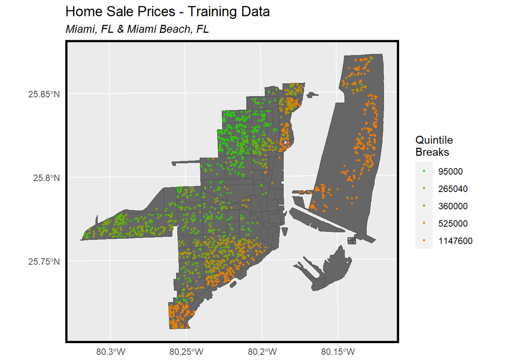

```r
ggplot() +
  geom_sf(data = miami.nhoods, fill = "grey40") +
  geom_sf(data = trainSet.sf, aes(colour = q5(SalePrice)),
          show.legend = "point", size = .75) +
  scale_colour_manual(values = palette5,
                   labels=qBr(trainSet.sf,"SalePrice"),
                   name="Quintile\nBreaks") +
  labs(title="Home Sale Prices - Training Data",
      subtitle="Miami, FL & Miami Beach, FL") +
  mapTheme()
```

## Exploratory Data Analysis: Which Internal Features to Include?

### Visualizing Correlations on Continuous Internal Features

In this series of scatterplots, the three continuous internal home feature variables are shown. The direction and magnitude of the least squares lines indicate that there is a correlation between sale price and each of these internal home features.

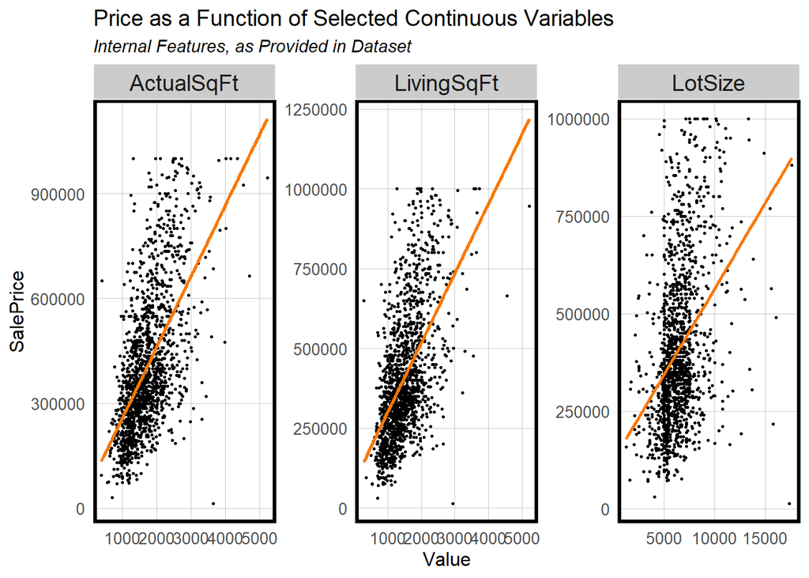

```r
st_drop_geometry(trainSet.sf) %>%
  dplyr::select(SalePrice, ActualSqFt, LivingSqFt, LotSize) %>%
  filter(SalePrice <= 1000000) %>%
  gather(Variable, Value, -SalePrice) %>%
   ggplot(aes(Value, SalePrice)) +
     geom_point(size = .5) + geom_smooth(method = "lm", se=F, colour = "#FA7800") +
     facet_wrap(~Variable, ncol = 3, scales = "free") +
     labs(title = "Price as a Function of Selected Continuous Variables",
          subtitle = "Internal Features, as Provided in Dataset") +
     plotTheme()
```

### Exploratory Correlation Matrix for All Numeric Variables

This correlation matrix shows the relationships between all numeric variables - both the ones we choose to include in the models and those that we do not. Looking at this matrix helps us identify which variables to explore further.

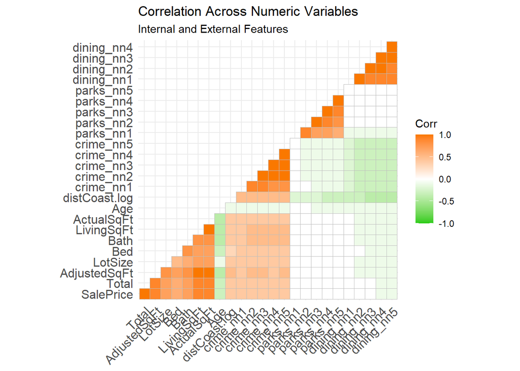

```r
numericVars <-
  select_if(st_drop_geometry(trainSet.sf), is.numeric) %>%
  na.omit() %>%
  dplyr::select(-Folio, -YearBuilt,-WVDB, -HEX, -County.2nd.HEX, -City.2nd.HEX, -saleType, -County.LongTermSenior, -County.Senior, -County.Other.Exempt, -County.Taxable, -City.LongTermSenior, -City.Senior, -City.Other.Exempt, -observation, MillCode, -City.Taxable, -MillCode, -EffectiveYearBuilt, -Land, -Units, -Bldg, -ELEV, -Stories, -Assessed, -distCoast)

ggcorrplot(
  round(cor(numericVars), 1),
  p.mat = cor_pmat(numericVars),
  colors = c("#25CB10", "white", "#FA7800"),
  type="lower",
  insig = "blank") +
    labs(title = "Correlation Across Numeric Variables",
         subtitle = "Internal and External Features")
```

## Exploratory Data Analysis: Which External Features to Include?

The following series shows some of the features we decide to take a closer look at and determine whether or not to include in our model.

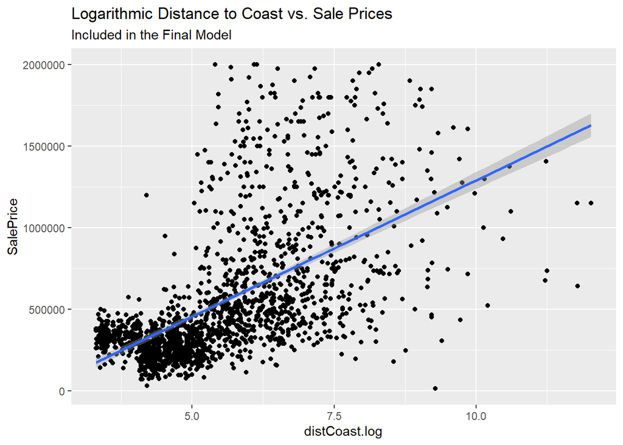

```r
distCoastlog.cor <-
  cor.test(trainSet.sf$distCoast.log, trainSet.sf$SalePrice, method = "pearson")

ggplot(filter(trainSet.sf, SalePrice <= 2000000), aes(y = SalePrice, x = distCoast.log)) +
  geom_point() +
  geom_smooth(method = "lm") +
   labs(title = "Logarithmic Distance to Coast vs. Sale Prices",
         subtitle = "Included in the Final Model")
```

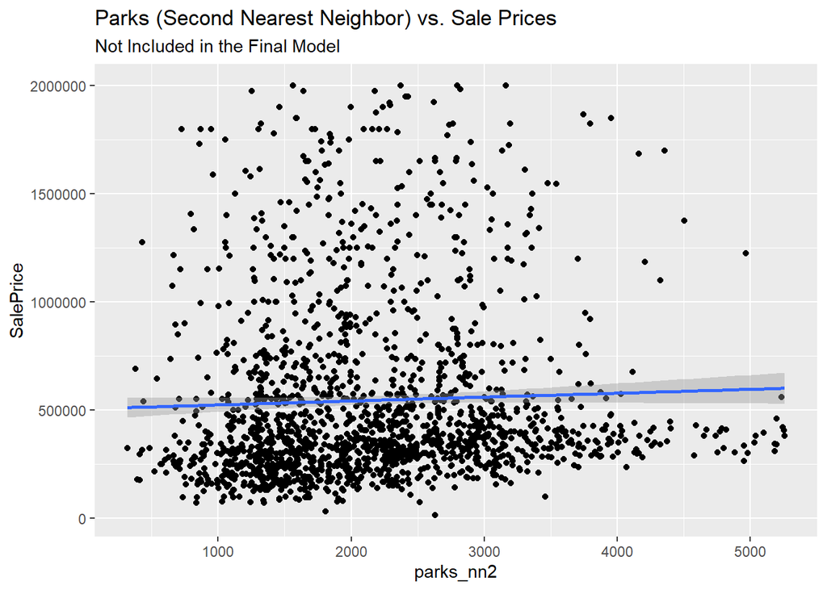

```r
parks.cor <-
  cor.test(trainSet.sf$parks_nn2, trainSet.sf$SalePrice, method = "pearson")

ggplot(filter(trainSet.sf, SalePrice <= 2000000), aes(y = SalePrice, x = parks_nn2)) +
  geom_point() +
  geom_smooth(method = "lm")+
  labs(title = "Parks (Second Nearest Neighbor) vs. Sale Prices",
         subtitle = "Not Included in the Final Model")
```

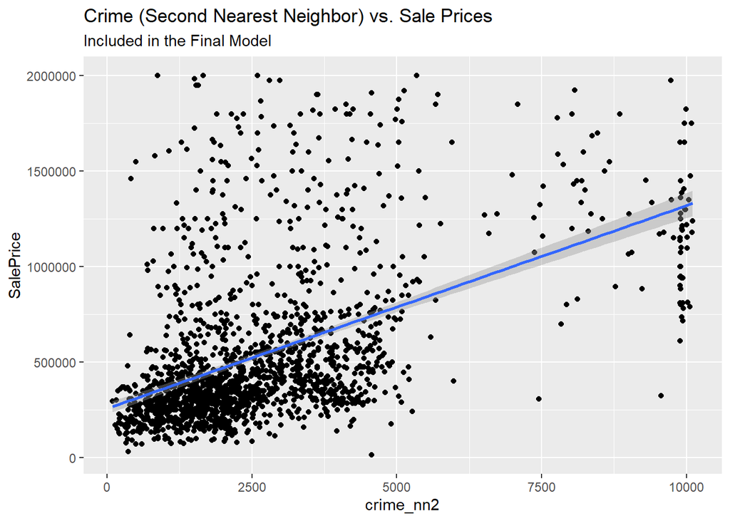

```r
crime.cor <-
  cor.test(trainSet.sf$crime_nn2, trainSet.sf$SalePrice, method = "pearson")

ggplot(filter(trainSet.sf, SalePrice <= 2000000), aes(y = SalePrice, x = crime_nn2)) +
  geom_point() +
  geom_smooth(method = "lm") +
  labs(title = "Crime (Second Nearest Neighbor) vs. Sale Prices",
         subtitle = "Included in the Final Model")
```

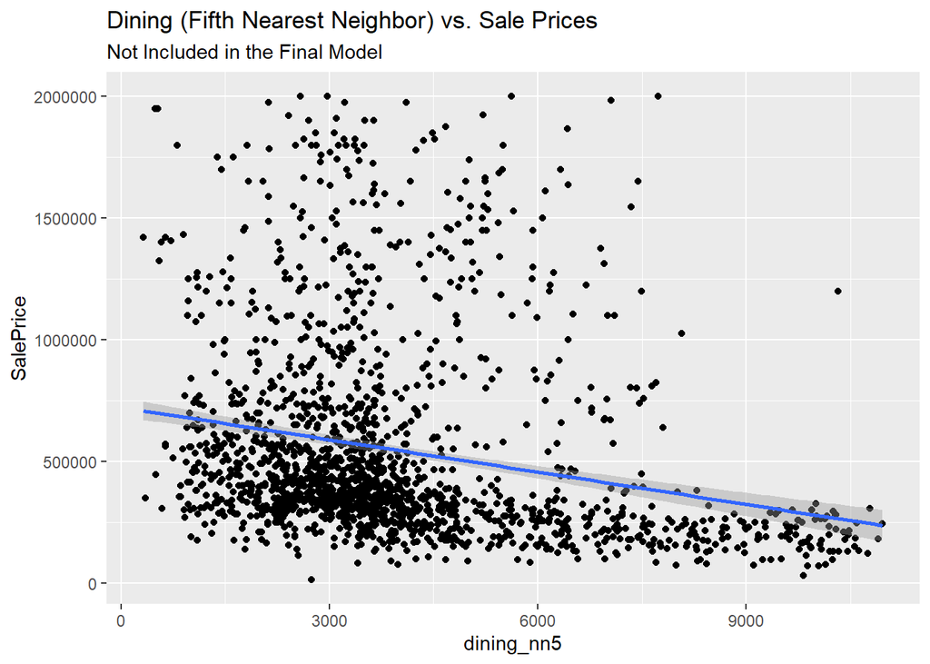

```r
dining.cor <-
  cor.test(trainSet.sf$dining_nn5, trainSet.sf$SalePrice, method = "pearson")

ggplot(filter(trainSet.sf, SalePrice <= 2000000), aes(y = SalePrice, x = dining_nn5)) +
  geom_point() +
  geom_smooth(method = "lm") +
  labs(title = "Dining (Fifth Nearest Neighbor) vs. Sale Prices",
         subtitle = "Not Included in the Final Model")
```

## Correlation Matrix for Selected Numeric Variables Used in Model Testing

After evaluating the correlations above, we determine that the following numeric variables will be used for developing our predictive model.

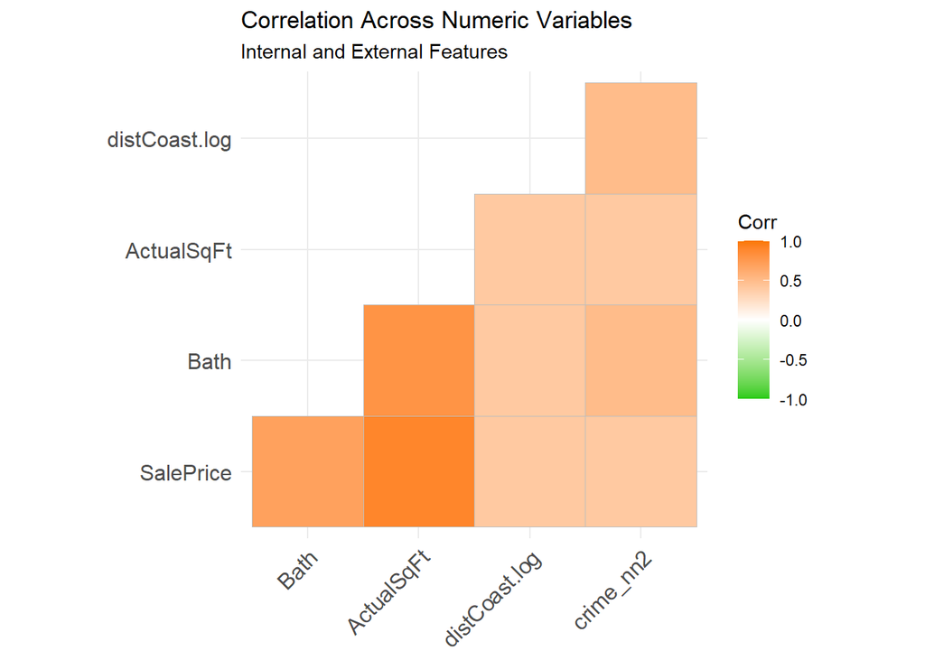

```r
### Corr matrix
numericVars <-
  select_if(st_drop_geometry(trainSet.sf), is.numeric) %>%
  na.omit() %>%
  dplyr::select(-Folio, -YearBuilt,-WVDB, -HEX, -County.2nd.HEX, -City.2nd.HEX, -saleType, -County.LongTermSenior, -County.Senior, -County.Other.Exempt, -County.Taxable, -City.LongTermSenior, -City.Senior, -City.Other.Exempt, -observation, MillCode, -City.Taxable, -MillCode, -EffectiveYearBuilt, -Land, -Units, -Bldg, -ELEV, -Stories, -Assessed, -distCoast, -starts_with("dining_"), -starts_with("parks_"), -crime_nn3, -crime_nn4, -crime_nn1, -crime_nn5, -Age, -Total, -Bed, -LotSize, -LivingSqFt, -AdjustedSqFt)

ggcorrplot(
  round(cor(numericVars), 1),
  p.mat = cor_pmat(numericVars),
  colors = c("#25CB10", "white", "#FA7800"),
  type="lower",
  insig = "blank") +
    labs(title = "Correlation Across Numeric Variables",
         subtitle = "Internal and External Features")
```

## Visualizing Mean Sale Price on Categorical Features

We repeat the same process for our categorical variables, but using bar plots.

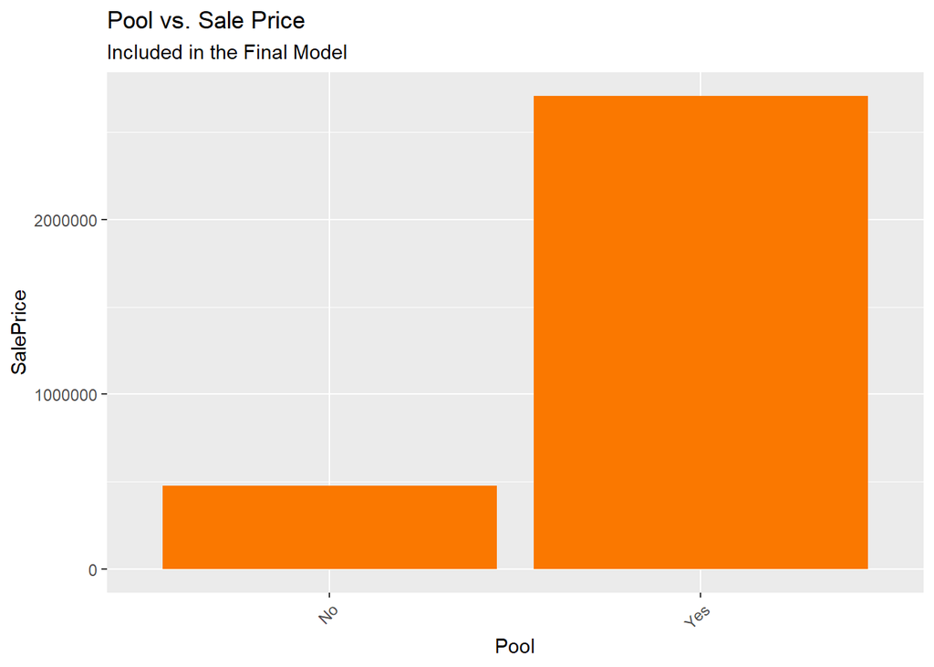

```r
## Using mean price on categorical features
trainSet.sf %>%
ggplot(aes(Pool, SalePrice)) +
     geom_bar(position = "dodge", stat = "summary", fill="#FA7800") +
    labs(title = "Pool vs. Sale Price",
         subtitle = "Included in the Final Model") +
  theme(axis.text.x = element_text(angle = 45, hjust = 1))
```

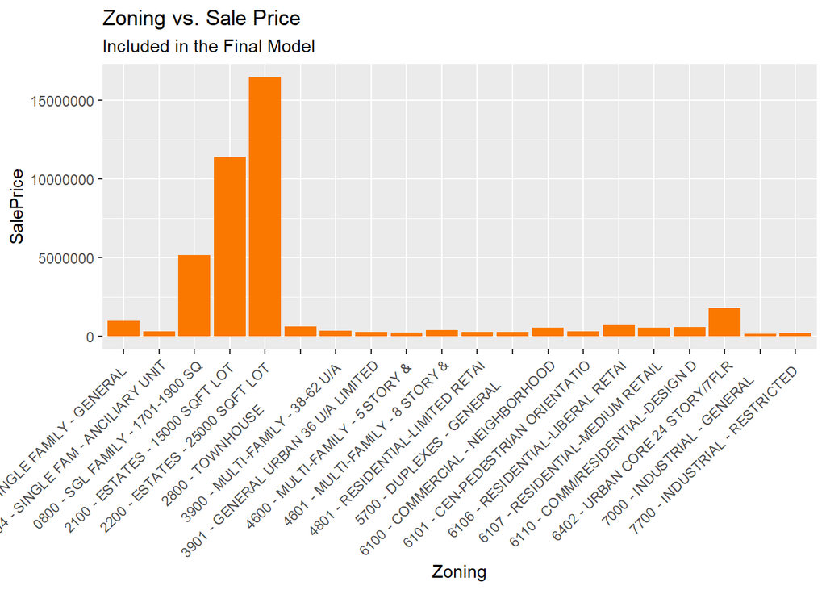

```r
trainSet.sf %>%
ggplot(aes(Zoning, SalePrice)) +
     geom_bar(position = "dodge", stat = "summary", fill="#FA7800") +
    labs(title = "Zoning vs. Sale Price",
         subtitle = "Included in the Final Model") +
 theme(axis.text.x = element_text(angle = 45, hjust = 1))
```

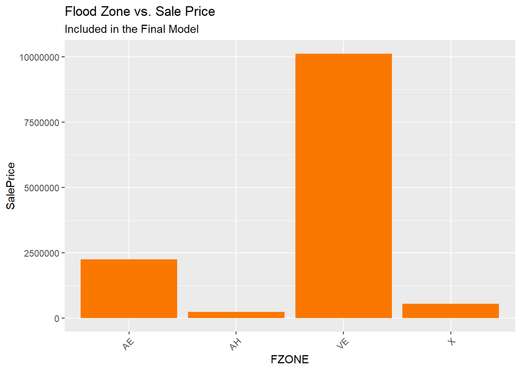

```r
trainSet.sf %>%
ggplot(aes(FZONE, SalePrice)) +
     geom_bar(position = "dodge", stat = "summary", fill="#FA7800") +
    labs(title = "Flood Zone vs. Sale Price",
         subtitle = "Included in the Final Model") +
  theme(axis.text.x = element_text(angle = 45, hjust = 1))
```

# Results

## Training Set Multivariate Regression

In the above analysis, we were able to view how each individual feature affected its past sales price. However, a combination of features are attributed to a single home affecting value in a different way depending on the quality of those features. For instance, a 4 bed 4 bath home with a pool may sell for a much higher price than a 4 bed 4 bath home without a pool. The unique interaction among our features and their combined influence on sales price is why we use statistical models to predict future sales prices.

Our first model mirrors the mechanics of the analysis used to select our engineered features. It simply observes sales price as a function of ActualSqFt, Pool, distCoast.log, and crime_nn2.

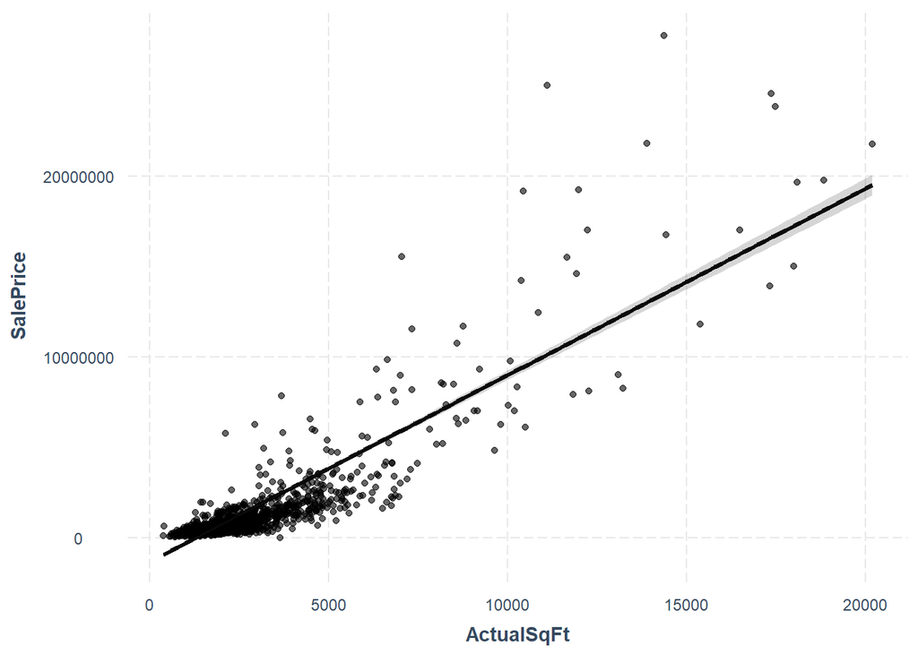

```r
reg2 <- lm(SalePrice ~ ., data = st_drop_geometry(trainSet.sf) %>%
                                 dplyr::select(SalePrice, ActualSqFt, Pool, distCoast.log, crime_nn2))

## Plot of marginal response
effect_plot(reg2, pred = ActualSqFt, interval = TRUE, plot.points = TRUE)
```

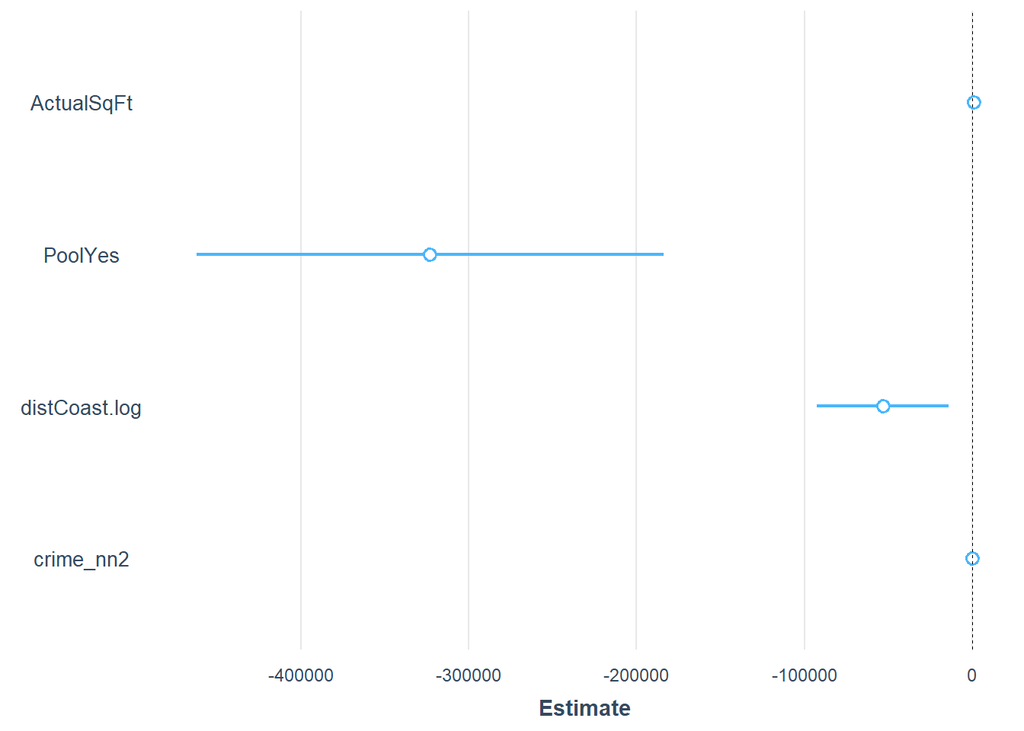

```r
## Plot coefficients
plot_summs(reg2)
```

```r
reg2table <- broom::glance(reg2)
```

```r
kbl(reg2table) %>% kable_styling(bootstrap_options = c("condensed", "responsive"))
```

| r.squared | adj.r.squared | sigma | statistic | p.value | df | logLik | AIC | BIC | deviance | df.residual | nobs |
| --- | --- | --- | --- | --- | --- | --- | --- | --- | --- | --- | --- |
| 0.771447 | 0.7709651 | 1092904 | 1600.761 | 0 | 4 | -29142.39 | 58296.78 | 58330.08 | 2265850721985143 | 1897 | 1902 |

```r
summ(reg2)
```

| Observations | 1902 |
| --- | --- |
| Dependent variable | SalePrice |
| Type | OLS linear regression |

| F(4,1897) | 1600.76 |
| --- | --- |
| R² | 0.77 |
| Adj. R² | 0.77 |

|  | Est. | S.E. | t val. | p |
| --- | --- | --- | --- | --- |
| (Intercept) | -1267241.98 | 100616.50 | -12.59 | 0.00 |
| ActualSqFt | 1031.75 | 15.98 | 64.57 | 0.00 |
| PoolYes | -323202.99 | 71007.03 | -4.55 | 0.00 |
| distCoast.log | -53149.12 | 20062.16 | -2.65 | 0.01 |
| crime_nn2 | 79.93 | 13.53 | 5.91 | 0.00 |

Standard errors: OLS

```r
reg2_predict <- predict(reg2, newdata = validSet.sf)
```

```r
## Mean Square Error train and test
rmse.train <- caret::MAE(predict(reg2), trainSet.sf$SalePrice)
rmse.valid  <- caret::MAE(reg2_predict, validSet.sf$SalePrice)
```

We can use this first model to predict sales prices for homes in our validation dataset. Because we know the past sales prices for this set, we can compare the actual sales prices to our predictions to calculate errors and determine the accuracy of the model.

```r
cat("Train MAE: ", as.integer(rmse.train), " \n","Valid MAE: ", as.integer(rmse.valid))
```

[output not shown]

The resulting errors are fairly high, indicating that we may want to use a different model to get more accurate predictions. Additionally, we consider that this model is best fit to houses specific to our training set and errors may be caused by their unique combinations of features.

The figures below visualize the results of the model, comparing predictions to actual values after the model is applied to the validation data set.

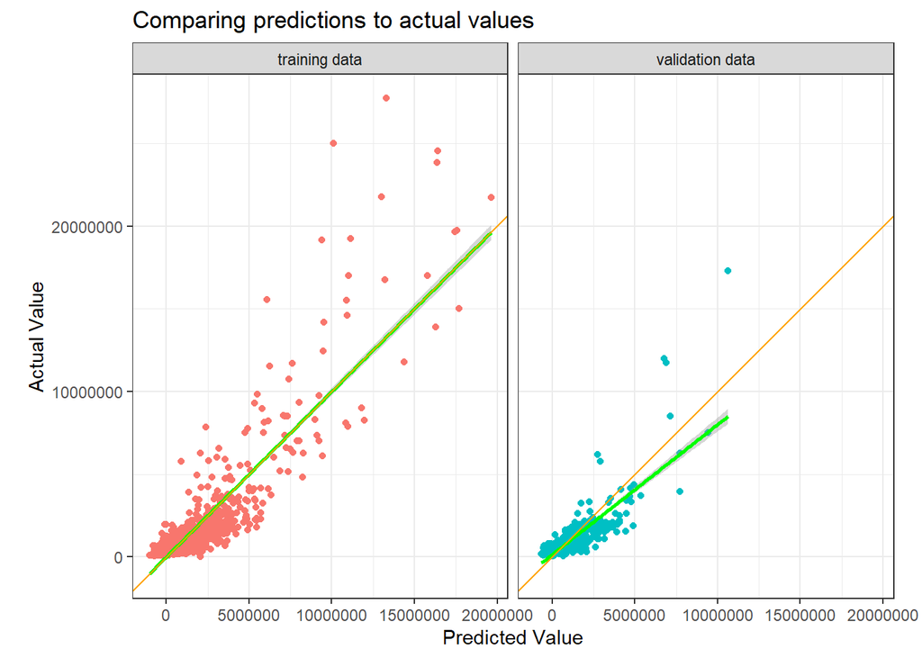

```r
preds.train <- data.frame(pred   = predict(reg2),
                          actual = trainSet.sf$SalePrice,
                          source = "training data")
preds.valid  <- data.frame(pred   = reg2_predict,
                          actual = validSet.sf$SalePrice,
                          source = "validation data")
preds <- rbind(preds.train, preds.valid)

ggplot(preds, aes(x = pred, y = actual, color = source)) +
  geom_point() +
  geom_smooth(method = "lm", color = "green") +
  geom_abline(color = "orange") +
  coord_equal() +
  theme_bw() +
  facet_wrap(~source, ncol = 2) +
  labs(title = "Comparing predictions to actual values",
       x = "Predicted Value",
       y = "Actual Value") +
  theme(
    legend.position = "none"
  )
```

## K-Fold Cross-Validation Test

The next model we try is a k-fold cross-validation test. In this test, we are able to address potential issues caused by our unique training dataset by running the test multiple times using different training datasets. Recall prior to our first model, we first split the data up into a group of known and unknown sales prices. Instead of splitting up the known sales price group, we will run this test on the entire group.

The test will partition the known sales price group into 100 equal sized subsets to train and predict on. Because all actual sales prices are known in this group, we can then compare predictions to calculate errors as we did before.

```r
fitControl <- trainControl(method = "cv",
                           number = 100,
                           # savePredictions differs from book
                           savePredictions = TRUE)
set.seed(825)

#adding nnparks to miamiTrain.sf DF
miamiTrain.sf <-
  miamiTrain.sf %>%
  st_transform('ESRI:102658') %>%
   mutate(
    parks_nn1 = nn_function(st_c(st_centroid(miamiTrain.sf)), st_c(st_centroid(parks.sf)), 1),
    parks_nn2= nn_function(st_c(st_centroid(miamiTrain.sf)), st_c(st_centroid(parks.sf)), 2),
    parks_nn3 = nn_function(st_c(st_centroid(miamiTrain.sf)), st_c(st_centroid(parks.sf)), 3),
    parks_nn4 = nn_function(st_c(st_centroid(miamiTrain.sf)), st_c(st_centroid(parks.sf)), 4),
    parks_nn5 = nn_function(st_c(st_centroid(miamiTrain.sf)), st_c(st_centroid(parks.sf)), 5))


miamiTrain.sf <-
  miamiTrain.sf %>%
    mutate(
      crime_nn1 = nn_function(st_c(st_centroid(miamiTrain.sf)), st_c(crimes.sf), 1),
      crime_nn2 = nn_function(st_c(st_centroid(miamiTrain.sf)), st_c(crimes.sf), 2),
      crime_nn3 = nn_function(st_c(st_centroid(miamiTrain.sf)), st_c(crimes.sf), 3),
      crime_nn4 = nn_function(st_c(st_centroid(miamiTrain.sf)), st_c(crimes.sf), 4),
      crime_nn5 = nn_function(st_c(st_centroid(miamiTrain.sf)), st_c(crimes.sf), 5))

miamiTrain.sf <-
  miamiTrain.sf %>%
  st_transform('ESRI:102658') %>%
   mutate(
    dining_nn1 = nn_function(st_c(st_centroid(miamiTrain.sf)), st_c(st_centroid(dining.sf)), 1),
    dining_nn2= nn_function(st_c(st_centroid(miamiTrain.sf)), st_c(st_centroid(dining.sf)), 2),
    dining_nn3 = nn_function(st_c(st_centroid(miamiTrain.sf)), st_c(st_centroid(dining.sf)), 3),
    dining_nn4 = nn_function(st_c(st_centroid(miamiTrain.sf)), st_c(st_centroid(dining.sf)), 4),
    dining_nn5 = nn_function(st_c(st_centroid(miamiTrain.sf)), st_c(st_centroid(dining.sf)), 5))
```

```r
#k fold cv model
reg.cv <-
  train(SalePrice ~ ., data = st_drop_geometry(miamiTrain.sf) %>%
                                dplyr::select(SalePrice, ActualSqFt, crime_nn2, Zoning, distCoast.log),
     method = "lm",
     trControl = fitControl,
     na.action = na.pass)

reg.cv
```

```
## Linear Regression
##
## 2477 samples
##    4 predictor
##
## No pre-processing
## Resampling: Cross-Validated (100 fold)
## Summary of sample sizes: 2453, 2451, 2451, 2452, 2453, 2453, ...
## Resampling results:
##
##   RMSE      Rsquared  MAE
##   790285.1  0.818428  456563.5
##
## Tuning parameter 'intercept' was held constant at a value of TRUE
```

The three figures below show the results of the k-fold cross validation test.

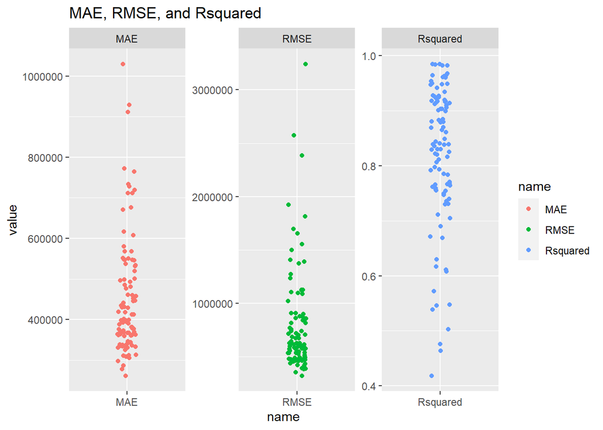

```r
#reg.cv$resample

reg.cv$resample %>%
  pivot_longer(-Resample) %>%
  mutate(name = as.factor(name)) %>%
  ggplot(., aes(x = name, y = value, color = name)) +
  geom_jitter(width = 0.1) +
  facet_wrap(~name, ncol = 3, scales = "free") +
  labs(title="MAE, RMSE, and Rsquared")
```

```r
  theme_bw() +
  theme()
```

```r
#interpreting the spread
# extract predictions from CV object
cv_preds <- reg.cv$pred
# compare number of observations between data sets
nrow(miamiTrain.sf)
nrow(cv_preds)
```

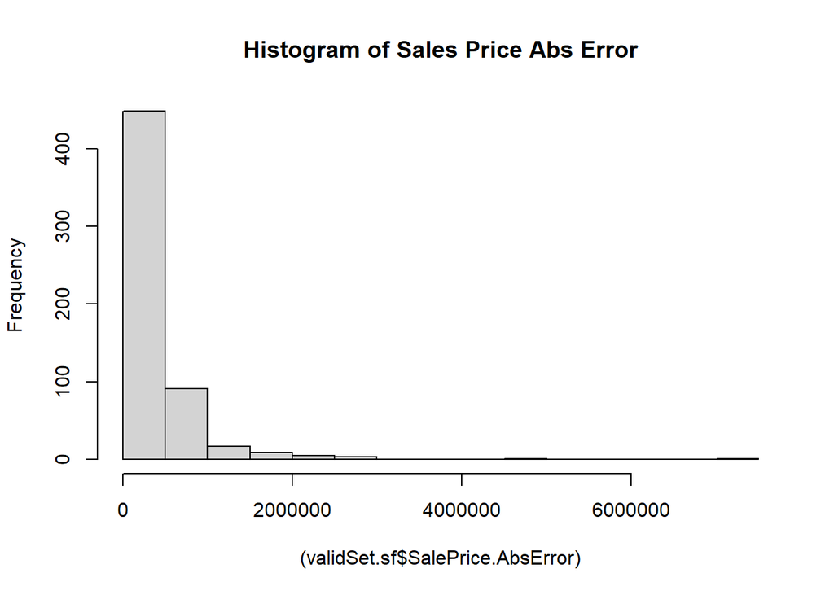

```r
#using CV regression model to predict on validSet to calculate errors attributed to sale price:
validSet.sf <-
  validSet.sf %>%
  mutate(Regression = "CV Regression",
         SalePrice.Predict = predict(reg.cv, validSet.sf),
         SalePrice.Error = SalePrice.Predict - SalePrice,
         SalePrice.AbsError = abs(SalePrice.Predict - SalePrice),
         SalePrice.APE = (abs(SalePrice.Predict - SalePrice)) / (SalePrice.Predict))
#%>% filter(SalePrice < 2000000)

#calculating MAE&MAPE to describe goodness of fit
#model is currently predicting negative sales prices so MAPE is negative
mean(validSet.sf$SalePrice, na.rm = T)
mean(validSet.sf$SalePrice.AbsError, na.rm = T)
mean(validSet.sf$SalePrice.APE, na.rm = T)

hist((validSet.sf$SalePrice.AbsError),main = paste("Histogram of Sales Price Abs Error"))
```

After observing results, we can adjust the features of the model to get more accurate predictions. ActualSqFt, crime_nn2, Zoning, and distCoast.log provide the lowest errors.

Because the resulting errors of this cross-validation test are lower than the first, it is a more accurate model. The resulting R^2 is also higher at ~0.82 indicating it is more generalizable to new data than the first model as this model was run for 100 subsets.

We can plot predicted prices as a function of observed prices to get a visualization of the test results. Because our green line is similar in slope and magnitude to the orange line, we can evaluate the accuracy of the model.

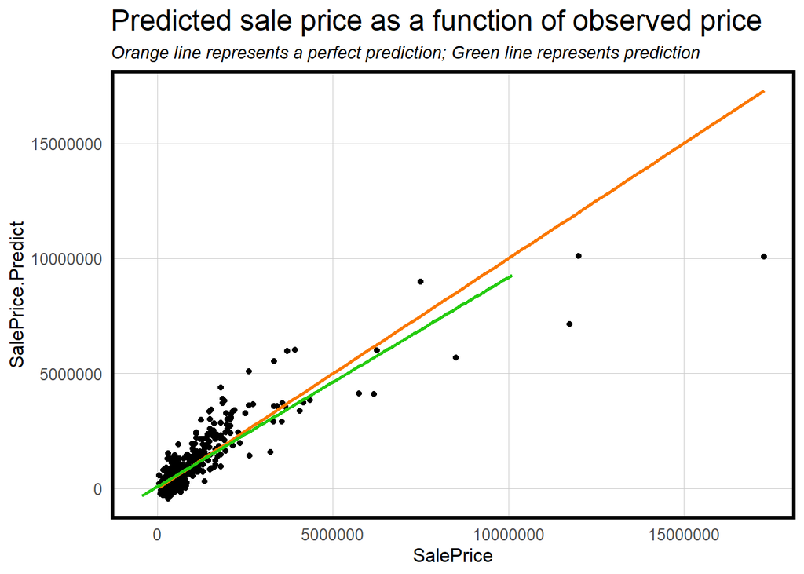

```r
validSet.sf %>%
  dplyr::select(SalePrice.Predict, SalePrice, Regression) %>%
    ggplot(aes(SalePrice, SalePrice.Predict)) +
  geom_point() +
  stat_smooth(aes(SalePrice, SalePrice),
             method = "lm", se = FALSE, size = 1, colour="#FA7800") +
  stat_smooth(aes(SalePrice.Predict, SalePrice),
              method = "lm", se = FALSE, size = 1, colour="#25CB10") +
  labs(title="Predicted sale price as a function of observed price",
       subtitle="Orange line represents a perfect prediction; Green line represents prediction") +
  plotTheme() + theme(plot.title = element_text(size = 18, colour = "black"))
```

This plot above tells us that the model is underpredicting sales prices as the orange line has a steeper slope than the green line. We can also observe clustering of sales prices that may be due to a spatial process not accounted for in this model.

```r
# Relating each salesPrice observation to nhoods
nhood.obs <-
  distinct(miamiHouses.sf, "Folio", .keep_all = TRUE)
coords <- st_coordinates(nhood.obs)
neighborList <- knn2nb(knearneigh(coords, 5))
spatialWeights <- nb2listw(neighborList, style="W")
nhood.obs$lagPrice <- lag.listw(spatialWeights, nhood.obs$SalePrice)
```

We perform further analysis on our errors by plotting them:

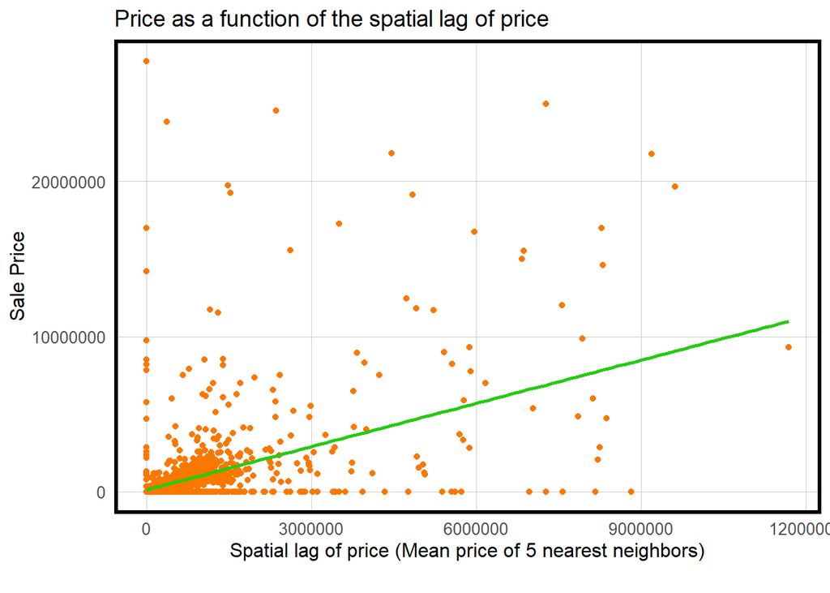

```r
coords.test <-  st_coordinates(validSet.sf)
neighborList.test <- knn2nb(knearneigh(coords.test, 5))
spatialWeights.test <- nb2listw(neighborList.test, style="W")
validSet.sf$lagPriceError <- lag.listw(spatialWeights.test, validSet.sf$SalePrice.AbsError)

ggplot(nhood.obs, aes(x=lagPrice, y=SalePrice)) +
   geom_point(colour = "#FA7800") +
   geom_smooth(method = "lm", se = FALSE, colour = "#25CB10") +
   labs(title = "Price as a function of the spatial lag of price",
        caption = "",
        x = "Spatial lag of price (Mean price of 5 nearest neighbors)",
        y = "Sale Price") +
   plotTheme()
```

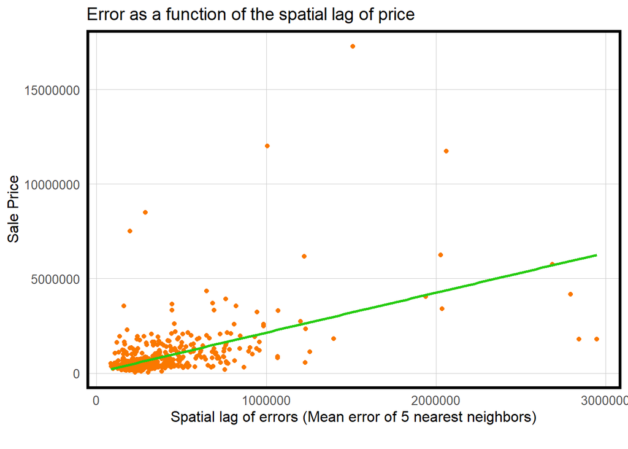

```r
ggplot(validSet.sf, aes(x=lagPriceError, y=SalePrice)) +
    geom_point(colour = "#FA7800") +
    geom_smooth(method = "lm", se = FALSE, colour = "#25CB10") +
    labs(title = "Error as a function of the spatial lag of price",
         caption = "",
         x = "Spatial lag of errors (Mean error of 5 nearest neighbors)",
         y = "Sale Price") +
    plotTheme()
```

Conducting a Moran’s I test on our errors will be able to tell us more about spatial clustering:

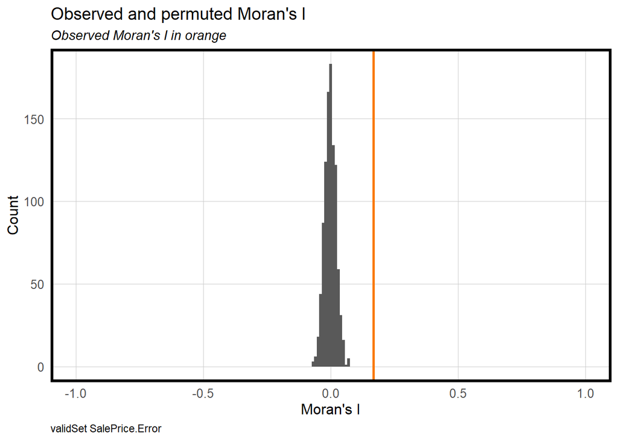

```r
## A Moran's I that is higher than our 999 random permutations confirms there is spatial autocorrelation in our model errors. In other words, variation in SalePrice is related to a spatial process that is currently omitted from our model.
moranTest <- moran.mc(validSet.sf$SalePrice.Error,
                      spatialWeights.test, nsim = 999)

ggplot(as.data.frame(moranTest$res[c(1:999)]), aes(moranTest$res[c(1:999)])) +
  geom_histogram(binwidth = 0.01) +
  geom_vline(aes(xintercept = moranTest$statistic), colour = "#FA7800",size=1) +
  scale_x_continuous(limits = c(-1, 1)) +
  labs(title="Observed and permuted Moran's I",
       subtitle= "Observed Moran's I in orange",
       x="Moran's I",
       y="Count",
       caption="validSet SalePrice.Error") +
  plotTheme()
```

The observed high Moran’s I indicates that the variance in sales price is related to a spatial process not accounted for in our model. Our next model will address this issue by incorporating a new neighborhood feature to account for clustering at the neighborhood level.

## Neighborhood Model

Similar to our very first model, this last model observes sales price as a function of neighborhood name, crime_nn2, Zoning, FZONE, distCoast.log, Pool. We can run the model multiple times and review its results to decide which features to include by identifying the combination yielding the lowest error results.

```r
left_join(
  st_drop_geometry(validSet.sf) %>%
    group_by(NAME) %>%
    summarize(meanPrice = mean(SalePrice, na.rm = T)),
    mutate(validSet.sf, predict.fe =
                        predict(lm(SalePrice ~ NAME, data = validSet.sf),
                        validSet.sf)) %>%
    st_drop_geometry %>%
    group_by(NAME) %>%
    summarize(meanPrediction = mean(predict.fe)))
```

```r
reg.nhood <- lm(SalePrice ~ ., data = as.data.frame(trainSet.sf) %>%
                                 dplyr::select(NAME, SalePrice, crime_nn2, Zoning, FZONE, distCoast.log, Pool))

validSet.sf.nhood <-
  validSet.sf %>%
  mutate(Regression = "Neighborhood Effects",
         SalePrice.Predict = predict(reg.nhood, validSet.sf),
         SalePrice.Error = (SalePrice - SalePrice.Predict),
         SalePrice.AbsError = abs(SalePrice - SalePrice.Predict),
         SalePrice.APE = (abs(SalePrice - SalePrice.Predict)) / SalePrice)


bothRegressions <-
  rbind(
    dplyr::select(validSet.sf, starts_with("SalePrice"), Regression, NAME) %>%
      mutate(lagPriceError = lag.listw(spatialWeights.test, SalePrice.Error)),
    dplyr::select(validSet.sf.nhood, starts_with("SalePrice"), Regression, NAME) %>%
      mutate(lagPriceError = lag.listw(spatialWeights.test, SalePrice.Error)))

st_drop_geometry(bothRegressions) %>%
  gather(Variable, Value, -Regression, -NAME) %>%
  filter(Variable == "SalePrice.AbsError" | Variable == "SalePrice.APE") %>%
  group_by(Regression, Variable) %>%
    summarize(meanValue = mean(Value, na.rm = T)) %>%
    spread(Variable, meanValue) %>%
    kable() %>% kable_styling(bootstrap_options = c("striped", "condensed", "responsive", fixed_thead=T, font_size=10, bold=T)) %>% row_spec(1, color = "black", background = "#25CB10") %>%
      row_spec(2, color = "black", background = "#FA7800")
```

| Regression | SalePrice.AbsError | SalePrice.APE |
| --- | --- | --- |
| CV Regression | 388772.8 | 8.4800472 |
| Neighborhood Effects | 344028.1 | 0.3694875 |

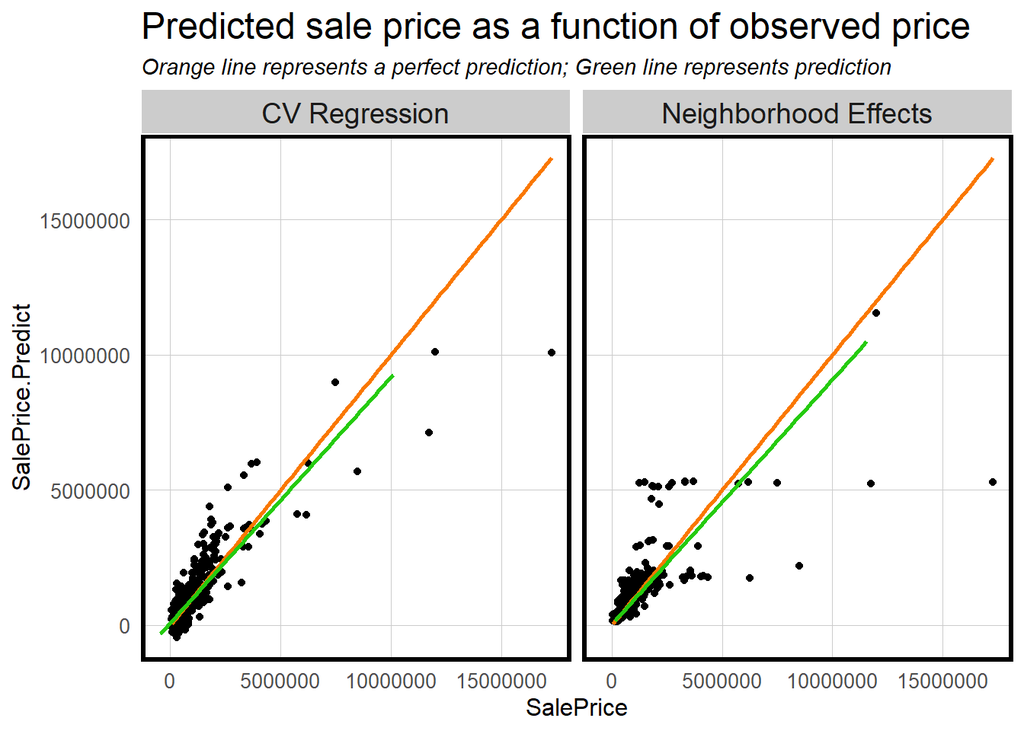

```r
bothRegressions %>%
  dplyr::select(SalePrice.Predict, SalePrice, Regression) %>%
    ggplot(aes(SalePrice, SalePrice.Predict)) +
  geom_point() +
  stat_smooth(aes(SalePrice, SalePrice),
             method = "lm", se = FALSE, size = 1, colour="#FA7800") +
  stat_smooth(aes(SalePrice.Predict, SalePrice),
              method = "lm", se = FALSE, size = 1, colour="#25CB10") +
  facet_wrap(~Regression) +
  labs(title="Predicted sale price as a function of observed price",
       subtitle="Orange line represents a perfect prediction; Green line represents prediction") +
  plotTheme() + theme(plot.title = element_text(size = 18, colour = "black"))
```

### MAPE by Neighborhood

Because this model considers spatial clustering at a neighborhood scale, we can observe the mean aboslute percentage error by neighborhood:

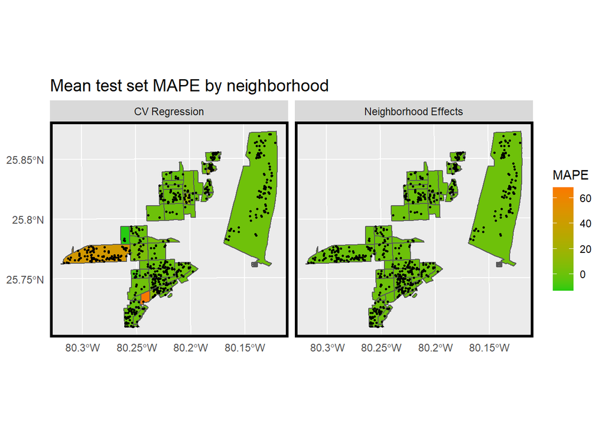

```r
st_drop_geometry(bothRegressions) %>%
  group_by(Regression, NAME) %>%
  summarize(mean.MAPE = mean(SalePrice.APE, na.rm = T)) %>%
  ungroup() %>%
  left_join(miami.nhoods) %>%
    st_sf() %>%
    ggplot() +
      geom_sf(aes(fill = mean.MAPE)) +
      geom_sf(data = bothRegressions, colour = "black", size = .5) +
      facet_wrap(~Regression) +
      scale_fill_gradient(low = palette5[1], high = palette5[5],
                          name = "MAPE") +
      labs(title = "Mean test set MAPE by neighborhood") +
      mapTheme()
```

Compared to our cross-validation test, this map indicates that our neighborhood model has more consistent accuracy across neighborhoods, and thus is more generalizable.

### Neighborhood Mean MAPE as a Function of Mean Sale Price

This scatterplot shows that as neighborhoods increase in average home sale price, the higher the neighborhood model’s errors are. This may have to do with the large variation in price of the wealthiest neighborhoods. This scatterplot indicates that we should explore what factors may be affecting sales prices in the wealthy neighborhoods as an additional feature in future model iterations.

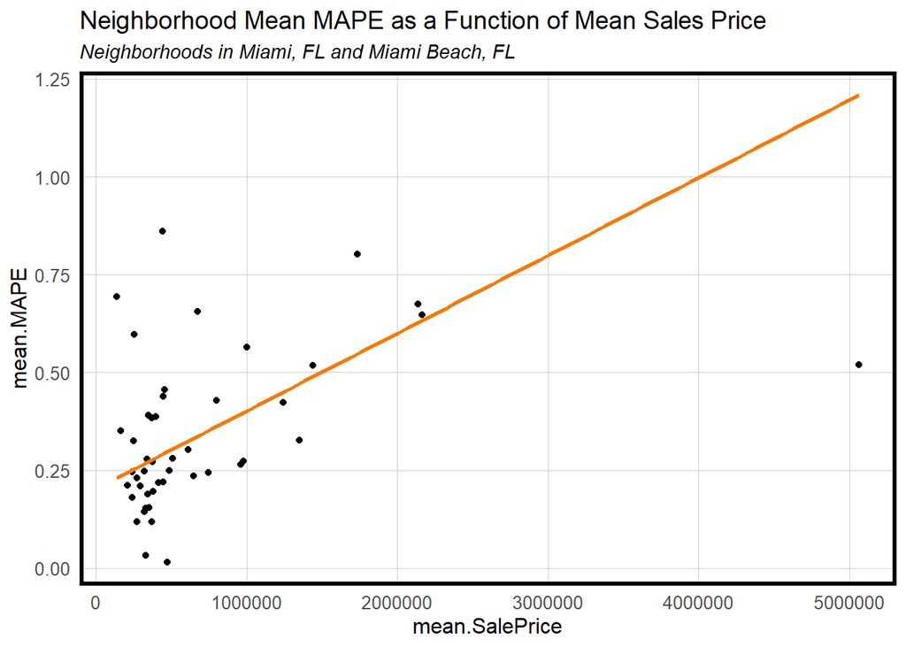

```r
bothRegressions_nhoodMAPE <-
  filter(bothRegressions, Regression=="Neighborhood Effects") %>%
  group_by(NAME) %>%
  dplyr::mutate(mean.MAPE=mean(SalePrice.APE, na.rm=T)) %>%
  dplyr::mutate(mean.SalePrice=mean(SalePrice, na.rm=T))


 ggplot(data=bothRegressions_nhoodMAPE, aes(x=mean.SalePrice, y = mean.MAPE)) +
  geom_point()+
  geom_smooth(method = "lm", se = FALSE, size = 1, colour="#FA7800") +
  labs(title="Neighborhood Mean MAPE as a Function of Mean Sales Price",
       subtitle="Neighborhoods in Miami, FL and Miami Beach, FL") +
   theme(legend.position="bottom")+
  plotTheme()
```

```r
# add census API key - make sure to replace this with your own API key!
census_api_key("41e1c0d912341017fa6f36a5da061d3b23de335e", overwrite = TRUE)

#can totally add more, just starting with basic ones
acs_vars_miamidade <- c("B02001_001E", # Estimate!!Total population by race
                        "B02001_002E", # People describing themselves as "white alone"
                        "B25058_001E", # Median rent
                        "B19013_001E", # Median HH Income
                        "B06012_002E") # Poverty

tracts2017 <-
  get_acs(geography = "tract",
          variables = acs_vars_miamidade,
          year=2017,
          state=12,
          county=086,
          geometry=T,
          output="wide") %>%
  st_transform('ESRI:102658') %>%
  rename(TotalPop = B02001_001E,
         White = B02001_002E,
         MedRent = B25058_001E,
         MedHHInc = B19013_001E,
         TotalPoverty = B06012_002E) %>%
  dplyr::select(-NAME, -starts_with("B")) %>%
  mutate(pctWhite = (ifelse(TotalPop > 0, White / TotalPop,0)),
         pctNotWhite = (1- pctWhite),
         pctPoverty = ifelse(TotalPop > 0, TotalPoverty / TotalPop, 0)) %>%
  dplyr::select(-White, -TotalPoverty)

#joining tracts and the data
# miamiHouses.sf<- st_join(miamiHouses.sf, tracts2017, join = st_within)
```

Lastly, we use US Census data to further test our neighborhood model’s generalizability. The below maps provide race and income context for census tracts that fall within both Miami and Miami Beach. Not that there are some industrial neighborhoods without any residential houses present in our prediction set, and so they do not show up in the map.

```r
tracts17.nhood <-
  tracts2017 %>%
  mutate(raceContext = ifelse(pctWhite > .5, "Majority White", "Majority Non-White"),
         incomeContext = ifelse(MedHHInc > 49930, "High Income", "Low Income")) %>%
  st_transform(st_crs(miami.nhoods))

tracts17.nhood <- st_join(tracts17.nhood, miami.nhoods)
```

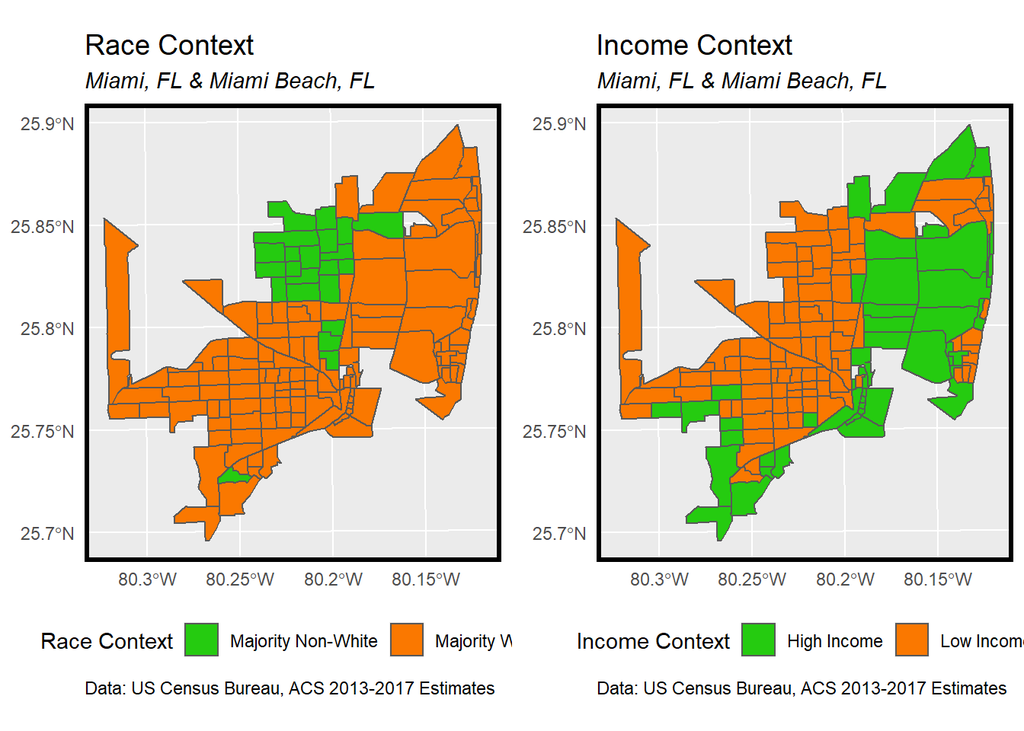

```r
grid.arrange(ncol = 2,
    ggplot()+
      geom_sf(data = na.omit(tracts17.nhood), aes(fill = raceContext)) +
    scale_fill_manual(values = c("#25CB10", "#FA7800"), name="Race Context") +
    labs(title = "Race Context", subtitle = "Miami, FL & Miami Beach, FL", caption="Data: US Census Bureau, ACS 2013-2017 Estimates") +
    mapTheme() + theme(legend.position="bottom"),
     ggplot() +
  geom_sf(data = na.omit(tracts17.nhood), aes(fill = incomeContext)) +
    scale_fill_manual(values = c("#25CB10", "#FA7800"), name="Income Context") +
    labs(title = "Income Context", subtitle = "Miami, FL & Miami Beach, FL", caption="Data: US Census Bureau, ACS 2013-2017 Estimates") +
    mapTheme() + theme(legend.position="bottom"))
```

We can use the two groups designated in each context map to calculate mean absolute percentage errors for our cross-validation test and neighborhood model.

```r
## income context race
st_join(bothRegressions, tracts17.nhood) %>%
  filter(!is.na(raceContext)) %>%
  group_by(Regression, raceContext) %>%
  summarize(mean.MAPE = scales::percent(mean(SalePrice.APE, na.rm = T))) %>%
  st_drop_geometry() %>%
  spread(raceContext, mean.MAPE) %>%
  kable(caption = "Test set MAPE by neighborhood race context") %>% kable_styling()
```

Test set MAPE by neighborhood race context

| Regression | Majority Non-White | Majority White |
| --- | --- | --- |
| CV Regression | 319% | 392% |
| Neighborhood Effects | 36% | 36% |

```r
## income context MAPE
st_join(bothRegressions, tracts17.nhood) %>%
  filter(!is.na(incomeContext)) %>%
  group_by(Regression, incomeContext) %>%
  summarize(mean.MAPE = scales::percent(mean(SalePrice.APE, na.rm = T))) %>%
  st_drop_geometry() %>%
  spread(incomeContext, mean.MAPE) %>%
  kable(caption = "Test set MAPE by neighborhood income context") %>% kable_styling()
```

Test set MAPE by neighborhood income context

| Regression | High Income | Low Income |
| --- | --- | --- |
| CV Regression | 318% | 428% |
| Neighborhood Effects | 40% | 32% |

We can use the two groups designated in each context map to calculate mean absolute percentage errors for our cross-validation test and neighborhood model.

```r
miamiTest.sf <-
  miamiTest %>%
  st_transform('ESRI:102658') %>%
   mutate(
    dining_nn1 = nn_function(st_c(st_centroid(miamiTest)), st_c(st_centroid(dining.sf)), 1),
    dining_nn2= nn_function(st_c(st_centroid(miamiTest)), st_c(st_centroid(dining.sf)), 2),
    dining_nn3 = nn_function(st_c(st_centroid(miamiTest)), st_c(st_centroid(dining.sf)), 3),
    dining_nn4 = nn_function(st_c(st_centroid(miamiTest)), st_c(st_centroid(dining.sf)), 4),
    dining_nn5 = nn_function(st_c(st_centroid(miamiTest)), st_c(st_centroid(dining.sf)), 5))

miamiTest.sf <-
  miamiTest.sf %>%
  st_transform('ESRI:102658') %>%
   mutate(
    crime_nn1 = nn_function(st_c(st_centroid(miamiTest.sf)), st_c(st_centroid(crimes.sf)), 1),
     crime_nn2= nn_function(st_c(st_centroid(miamiTest.sf)), st_c(st_centroid(crimes.sf)), 2),
     crime_nn3 = nn_function(st_c(st_centroid(miamiTest.sf)), st_c(st_centroid(crimes.sf)), 3),
     crime_nn4 = nn_function(st_c(st_centroid(miamiTest.sf)), st_c(st_centroid(crimes.sf)), 4),
     crime_nn5 = nn_function(st_c(st_centroid(miamiTest.sf)), st_c(st_centroid(crimes.sf)), 5))

miamiTest.sf <-
  miamiTest.sf %>%
  st_transform('ESRI:102658') %>%
   mutate(
    parks_nn1 = nn_function(st_c(st_centroid(miamiTest.sf)), st_c(st_centroid(parks.sf)), 1),
    parks_nn2= nn_function(st_c(st_centroid(miamiTest.sf)), st_c(st_centroid(parks.sf)), 2),
    parks_nn3 = nn_function(st_c(st_centroid(miamiTest.sf)), st_c(st_centroid(parks.sf)), 3),
    parks_nn4 = nn_function(st_c(st_centroid(miamiTest.sf)), st_c(st_centroid(parks.sf)), 4),
    parks_nn5 = nn_function(st_c(st_centroid(miamiTest.sf)), st_c(st_centroid(parks.sf)), 5))
```

```r
test_predict1 <- predict(reg.nhood, miamiTest.sf)
miamiTest.sf$SalePrice <- test_predict1

output_preds <-
  data.frame(prediction = miamiTest.sf$SalePrice, Folio = miamiTest.sf$Folio, team_name = "The Real Houseprices of Miami")
#write.csv(output_preds, "The_Real_Houseprices_of_Miami.csv")
```

After determining the best fit features, we apply the model to our unknown sales price dataset to predict the unknown sales prices. The results can be visualized using the map below:

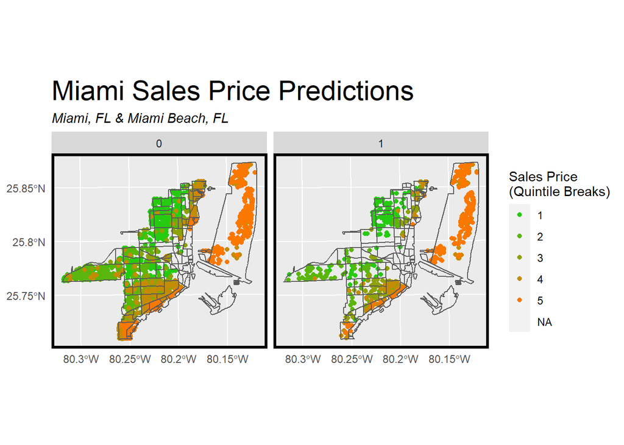

```r
train_predict1 <- predict(reg.nhood, miamiTrain.sf)

train_preds <-
miamiTrain.sf%>%
  mutate(SalePrice2 = train_predict1)

test_preds <-
  miamiTest.sf %>%
  dplyr::rename(SalePrice2 = SalePrice)%>%
  mutate(SalePrice = test_predict1)

total_preds <- rbind(test_preds, train_preds)

total_predsMap <-
  ggplot(total_preds)+
  geom_sf(aes(color = q5(SalePrice2)))+
  scale_color_manual(values = palette5,
                    #labels = qBr(total_preds$SalePrice2, "Sales Price Predictions"),
                    name = "Sales Price\n(Quintile Breaks)") +
  labs(title = "Miami Sales Price Predictions",
  subtitle = "Miami, FL & Miami Beach, FL")+
  geom_sf(data=miami.nhoods, fill='NA')+
  facet_wrap(~toPredict)+
  mapTheme() +
  theme(plot.title = element_text(size=22))
total_predsMap
```

Again, we see that the neighborhood model’s accuracy is more consistent across groups.

# Discussion

## Is this an effective model?

This is a somewhat effective model because we are able to predict across spatial variations in prices according to our neighborhood maps. The Moran’s I test results further confirm that spatial autocorrelation exists, drawing us to look at variable effects and variation at the neighborhood level.

## According to your maps, could you account the spatial variation in prices?

As shown in the results, the neighborhood model’s map shows that spatial variation exists in prices, especially across the Miami and Miami Beach groups. Because the errors are consistent across neighborhoods, we feel that this is a more generalizable model than the cross-validation test.

## Where did the model predict particularly well? Poorly?

The model predicted better in the city of Miami. This is likely due to the robustness of the open data that we used for Miami compared to Miami Beach. This is demonstrated through the crime variable: while the the crime mapping portal covers crime incidents across the county, incidents were reported in the city of Miami more frequently than for Miami Beach for the incident types and time period that we observed. In all of our tests, the crime nearest neighbor feature that we included showed statistical significance. It also improved the fit of the models - both cross-validation and neighborhood - when included.

The model was not as effective in predicting based on the distance to coast. In Miami Beach specifically, the variation in distance to coast is smaller compared to across the city of Miami, which makes this feature not as significant of a factor in house price prediction in Miami Beach. We hypothesize that there are other factors at play, such as the tourism industry and rental property presence in such a frequented vacation destination (Miami Beach) that are affecting home values.

## What were some of the more interesting variables? Describe the more important features.

Some our our most interesting variables were external features engineered in our data exploration section. One of these variables was our wrangled crime data for burglary and assault incidents. Given the attention that the Miami area receives around high crime rate, we felt it would be an asset to include. We were expecting crime - in any of the nearest neighbor distance ranges - to be significant. We decided to use crime nearest neighbor two because it accounted for exposure at close proximity to homes, but not at the highest granularity due to the block-level standardization of the data points.

We also felt that variables related to the question of flood risk - such as living in a FEMA flood risk insurance zone and distance to the coastline - were important to include. We also looked at elevation by bringing in a raster dataset of the 2015 5-ft Digital Elevation Model; however, adding in elevation on top of the other predictors proved redundant and was not a good fit for the model. This may be in part to the transformation of raster-level data to approximate address-level locations; a point-level topographic elevation dataset would be a better data source to investigate (such a digital model is not available through open data portals).

Zoning turned out to be important internal variable to include in our model. The zoning variable we did not originally think to factor in; however, after looking the zoning maps of the cities, we realized there were probably spatial processes previously omitted from the model, similar to the neighborhood fixed effect.

# Conclusion

We would recommend our neighborhood model to Zillow because it accounts for spatial processes - both neighborhood effects and property zoning - that drive clustering of house prices. It also takes into account additional features - both internal and external - that consider buyers’ preferences, which influence home values. Our model does well with generalizability, but it could improve with accuracy. Perhaps incorporating more features accounting for differences between Miami and Miami Beach could help alleviate variation between the two municipalities. This would require Zillow to work with the city to obtain more robust datasets on features like land use, while also obtaining incident data from more consistent crime reporting.